# NCDB Hemangiopericytoma

All

Jason Brant

August 23, 2018

**Note: To hide the code from this document, click the button in the upper right corner.**

```r
col.width <- c(37, 10, 1, 1, 3, 1, 2, 1, 2, 1, 1, 1, 1, 1, 1, 8, 2, 2, 2, 4, 4, 1, 4, 1, 1, 1, 3, 2, 2, 8,
               2, 5, 5, 5, 4, 5, 5, 5, 4, 2, 1, 2, 1, 3, 1, 1, 1, 1, 1, 1, 3, 3, 3, 3, 3, 3, 3, 3, 3, 3, 3,
               3, 3, 3, 3, 3, 3, 3, 3, 3, 3, 3, 3, 3, 3, 6, 8, 8, 8, 2, 1, 1, 1, 1, 8, 1, 1, 8, 1, 1, 2,
               2, 5, 2, 5, 3, 1, 3, 1, 8, 8, 2, 8, 2, 8, 2, 2, 1, 8, 1, 1, 1, 1, 1, 8, 1, 2, 2, 2, 2, 2,
               1, 1, 1, 2, 1)
col.names.abr <- c("PUF_CASE_ID", "PUF_FACILITY_ID", "FACILITY_TYPE_CD",  "FACILITY_LOCATION_CD", "AGE", "SEX", "RACE",
                   "SPANISH_HISPANIC_ORIGIN", "INSURANCE_STATUS", "MED_INC_QUAR_00", "NO_HSD_QUAR_00", "UR_CD_03",
                   "MED_INC_QUAR_12", "NO_HSD_QUAR_12", "UR_CD_13", "CROWFLY", "CDCC_TOTAL", "SEQUENCE_NUMBER",
                   "CLASS_OF_CASE", "YEAR_OF_DIAGNOSIS", "PRIMARY_SITE",  "LATERALITY", "HISTOLOGY", "BEHAVIOR",
                   "GRADE", "DIAGNOSTIC_CONFIRMATION", "TUMOR_SIZE", "REGIONAL_NODES_POSITIVE",
                   "REGIONAL_NODES_EXAMINED", "DX_STAGING_PROC_DAYS", "RX_SUMM_DXSTG_PROC", "TNM_CLIN_T",
                   "TNM_CLIN_N", "TNM_CLIN_M", "TNM_CLIN_STAGE_GROUP", "TNM_PATH_T", "TNM_PATH_N", "TNM_PATH_M",
                   "TNM_PATH_STAGE_GROUP", "TNM_EDITION_NUMBER", "ANALYTIC_STAGE_GROUP", "CS_METS_AT_DX",
                   "CS_METS_EVAL", "CS_EXTENSION", "CS_TUMOR_SIZEEXT_EVAL", "CS_METS_DX_BONE",
                   "CS_METS_DX_BRAIN", "CS_METS_DX_LIVER", "CS_METS_DX_LUNG", "LYMPH_VASCULAR_INVASION",
                   "CS_SITESPECIFIC_FACTOR_1", "CS_SITESPECIFIC_FACTOR_2", "CS_SITESPECIFIC_FACTOR_3",
                   "CS_SITESPECIFIC_FACTOR_4", "CS_SITESPECIFIC_FACTOR_5", "CS_SITESPECIFIC_FACTOR_6",
                   "CS_SITESPECIFIC_FACTOR_7", "CS_SITESPECIFIC_FACTOR_8", "CS_SITESPECIFIC_FACTOR_9",
                   "CS_SITESPECIFIC_FACTOR_10", "CS_SITESPECIFIC_FACTOR_11", "CS_SITESPECIFIC_FACTOR_12",
                   "CS_SITESPECIFIC_FACTOR_13", "CS_SITESPECIFIC_FACTOR_14", "CS_SITESPECIFIC_FACTOR_15",
                   "CS_SITESPECIFIC_FACTOR_16", "CS_SITESPECIFIC_FACTOR_17", "CS_SITESPECIFIC_FACTOR_18",
                   "CS_SITESPECIFIC_FACTOR_19", "CS_SITESPECIFIC_FACTOR_20", "CS_SITESPECIFIC_FACTOR_21",
                   "CS_SITESPECIFIC_FACTOR_22", "CS_SITESPECIFIC_FACTOR_23", "CS_SITESPECIFIC_FACTOR_24",
                   "CS_SITESPECIFIC_FACTOR_25", "CS_VERSION_LATEST", "DX_RX_STARTED_DAYS",
                   "DX_SURG_STARTED_DAYS", "DX_DEFSURG_STARTED_DAYS", "RX_SUMM_SURG_PRIM_SITE",
                   "RX_HOSP_SURG_APPR_2010", "RX_SUMM_SURGICAL_MARGINS", "RX_SUMM_SCOPE_REG_LN_SUR",
                   "RX_SUMM_SURG_OTH_REGDIS", "SURG_DISCHARGE_DAYS", "READM_HOSP_30_DAYS",
                   "REASON_FOR_NO_SURGERY", "DX_RAD_STARTED_DAYS", "RX_SUMM_RADIATION", "RAD_LOCATION_OF_RX",
                   "RAD_TREAT_VOL", "RAD_REGIONAL_RX_MODALITY", "RAD_REGIONAL_DOSE_CGY",
                   "RAD_BOOST_RX_MODALITY", "RAD_BOOST_DOSE_CGY", "RAD_NUM_TREAT_VOL",
                   "RX_SUMM_SURGRAD_SEQ", "RAD_ELAPSED_RX_DAYS", "REASON_FOR_NO_RADIATION",
                   "DX_SYSTEMIC_STARTED_DAYS", "DX_CHEMO_STARTED_DAYS", "RX_SUMM_CHEMO",
                   "DX_HORMONE_STARTED_DAYS", "RX_SUMM_HORMONE", "DX_IMMUNO_STARTED_DAYS",
                   "RX_SUMM_IMMUNOTHERAPY", "RX_SUMM_TRNSPLNT_ENDO", "RX_SUMM_SYSTEMIC_SUR_SEQ",
                   "DX_OTHER_STARTED_DAYS", "RX_SUMM_OTHER", "PALLIATIVE_CARE", "RX_SUMM_TREATMENT_STATUS",
                   "PUF_30_DAY_MORT_CD", "PUF_90_DAY_MORT_CD", "DX_LASTCONTACT_DEATH_MONTHS",
                   "PUF_VITAL_STATUS", "RX_HOSP_SURG_PRIM_SITE", "RX_HOSP_CHEMO", "RX_HOSP_IMMUNOTHERAPY",
                   "RX_HOSP_HORMONE", "RX_HOSP_OTHER", "PUF_MULT_SOURCE", "REFERENCE_DATE_FLAG",
                   "RX_SUMM_SCOPE_REG_LN_2012", "RX_HOSP_DXSTG_PROC", "PALLIATIVE_CARE_HOSP")
#Read in data for each subsite
bone.joint <- read_fwf('I:/Brant/Research/NCDB/Data/Data_2017/NCDB_PUF_DATA_Nov-07-2017/NCDBPUF_BoneJont.3.2015.0.dat',
                       fwf_widths(col.width, col_names = col.names.abr),
                       col_types = cols(.default = col_character()))
brain <- read_fwf('I:/Brant/Research/NCDB/Data/Data_2017/NCDB_PUF_DATA_Nov-07-2017/NCDBPUF_Brain.3.2015.0.dat',
                       fwf_widths(col.width, col_names = col.names.abr),
                       col_types = cols(.default = col_character()))
cns <- read_fwf('I:/Brant/Research/NCDB/Data/Data_2017/NCDB_PUF_DATA_Nov-07-2017/NCDBPUF_CNS.3.2015.0.dat',
                       fwf_widths(col.width, col_names = col.names.abr),
                       col_types = cols(.default = col_character()))
gum.ot.mth <- read_fwf('I:/Brant/Research/NCDB/Data/Data_2017/NCDB_PUF_DATA_Nov-07-2017/NCDBPUF_GumOtMth.3.2015.0.dat',
                       fwf_widths(col.width, col_names = col.names.abr),
                       col_types = cols(.default = col_character()))
hypophar <- read_fwf('I:/Brant/Research/NCDB/Data/Data_2017/NCDB_PUF_DATA_Nov-07-2017/NCDBPUF_Hypophar.3.2015.0.dat',
                       fwf_widths(col.width, col_names = col.names.abr),
                       col_types = cols(.default = col_character()))
larynx <- read_fwf('I:/Brant/Research/NCDB/Data/Data_2017/NCDB_PUF_DATA_Nov-07-2017/NCDBPUF_Larynx.3.2015.0.dat',
                       fwf_widths(col.width, col_names = col.names.abr),
                       col_types = cols(.default = col_character()))
lip <- read_fwf('I:/Brant/Research/NCDB/Data/Data_2017/NCDB_PUF_DATA_Nov-07-2017/NCDBPUF_Lip.3.2015.0.dat',
                       fwf_widths(col.width, col_names = col.names.abr),
                       col_types = cols(.default = col_character()))
melanoma <- read_fwf('I:/Brant/Research/NCDB/Data/Data_2017/NCDB_PUF_DATA_Nov-07-2017/NCDBPUF_Melanoma.3.2015.0.dat',
                       fwf_widths(col.width, col_names = col.names.abr),
                       col_types = cols(.default = col_character()))
fom <- read_fwf('I:/Brant/Research/NCDB/Data/Data_2017/NCDB_PUF_DATA_Nov-07-2017/NCDBPUF_MouthFlr.3.2015.0.dat',
                       fwf_widths(col.width, col_names = col.names.abr),
                       col_types = cols(.default = col_character()))
nasal <- read_fwf('I:/Brant/Research/NCDB/Data/Data_2017/NCDB_PUF_DATA_Nov-07-2017/NCDBPUF_Nasal.3.2015.0.dat',
                       fwf_widths(col.width, col_names = col.names.abr),
                       col_types = cols(.default = col_character()))
nasophar <- read_fwf('I:/Brant/Research/NCDB/Data/Data_2017/NCDB_PUF_DATA_Nov-07-2017/NCDBPUF_Nasophar.3.2015.0.dat',
                       fwf_widths(col.width, col_names = col.names.abr),
                       col_types = cols(.default = col_character()))
orophar <- read_fwf('I:/Brant/Research/NCDB/Data/Data_2017/NCDB_PUF_DATA_Nov-07-2017/NCDBPUF_Orophary.3.2015.0.dat',
                       fwf_widths(col.width, col_names = col.names.abr),
                       col_types = cols(.default = col_character()))
oth.endo <- read_fwf('I:/Brant/Research/NCDB/Data/Data_2017/NCDB_PUF_DATA_Nov-07-2017/NCDBPUF_OtEndocr.3.2015.0.dat',
                       fwf_widths(col.width, col_names = col.names.abr),
                       col_types = cols(.default = col_character()))
skin <- read_fwf('I:/Brant/Research/NCDB/Data/Data_2017/NCDB_PUF_DATA_Nov-07-2017/NCDBPUF_OtSkin.3.2015.0.dat',
                       fwf_widths(col.width, col_names = col.names.abr),
                       col_types = cols(.default = col_character()))
pharynx <- read_fwf('I:/Brant/Research/NCDB/Data/Data_2017/NCDB_PUF_DATA_Nov-07-2017/NCDBPUF_Pharynx.3.2015.0.dat',
                       fwf_widths(col.width, col_names = col.names.abr),
                       col_types = cols(.default = col_character()))
saliv.gland <- read_fwf('I:/Brant/Research/NCDB/Data/Data_2017/NCDB_PUF_DATA_Nov-07-2017/NCDBPUF_SalivGld.3.2015.0.dat',
                       fwf_widths(col.width, col_names = col.names.abr),
                       col_types = cols(.default = col_character()))
thyroid <- read_fwf('I:/Brant/Research/NCDB/Data/Data_2017/NCDB_PUF_DATA_Nov-07-2017/NCDBPUF_Thyroid.3.2015.0.dat',
                       fwf_widths(col.width, col_names = col.names.abr),
                       col_types = cols(.default = col_character()))
tongue <- read_fwf('I:/Brant/Research/NCDB/Data/Data_2017/NCDB_PUF_DATA_Nov-07-2017/NCDBPUF_Tongue.3.2015.0.dat',
                       fwf_widths(col.width, col_names = col.names.abr),
                       col_types = cols(.default = col_character()))
tonsil <- read_fwf('I:/Brant/Research/NCDB/Data/Data_2017/NCDB_PUF_DATA_Nov-07-2017/NCDBPUF_Tonsil.3.2015.0.dat',
                       fwf_widths(col.width, col_names = col.names.abr),
                       col_types = cols(.default = col_character()))
trach.med <- read_fwf('I:/Brant/Research/NCDB/Data/Data_2017/NCDB_PUF_DATA_Nov-07-2017/NCDBPUF_TrachMed.3.2015.0.dat',
                       fwf_widths(col.width, col_names = col.names.abr),
                       col_types = cols(.default = col_character()))
#Combine data for all subsites
dat <- bind_rows(bone.joint, brain, cns, gum.ot.mth, hypophar, larynx, lip, melanoma, fom, nasal, nasophar, orophar,
                 oth.endo, skin, pharynx, saliv.gland, thyroid, tongue, tonsil, trach.med)
rm(bone.joint, brain, cns, gum.ot.mth, hypophar, larynx, lip, melanoma, fom, nasal, nasophar, orophar,
                 oth.endo, skin, pharynx, saliv.gland, thyroid, tongue, tonsil, trach.med)
prim_site_text <- data_frame(PRIMARY_SITE = c("C030", "C031", "C062", "C039", "C050", "C051", "C052", "C058", "C059", "C068",
               "C069", "C060", "C061", "C129", "C130", "C131", "C132", "C138", "C139", "C320",
               "C321", "C322", "C323", "C328", "C329", "C000", "C003", "C001", "C004", "C006",
               "C002", "C005", "C008", "C009", "C440", "C442", "C443", "C444", "C445", "C446",
               "C447", "C448", "C449", "C441", "C040", "C041", "C048", "C049", "C300", "C301",
               "C310", "C311", "C312", "C313", "C318", "C319", "C110", "C111", "C112", "C113",
               "C118", "C119", "C090", "C091", "C098", "C099", "C100", "C102", "C103", "C104",
               "C108", "C109", "C101", "C140", "C142", "C148", "C079", "C080", "C081", "C088",
               "C089", "C739", "C019", "C024", "C020", "C021", "C022", "C023", "C028", "C029"),
               SITE_TEXT = c("C03.0: Gum, upper", "C03.1 Gum, lower", "C06.2 Retromolar area", "C03.9 Gum, NOS",
               "C05.0 Hard Palate", "C05.1 Soft Palate", "C05.2 Uvula", "C05.8 Overlapping lesion of palate",
               "C05.9 Palate NOS", "C06.8 Overlapping lesion of other an unspecified parts of mouth",
               "C06.9 Mouth, NOS", "C06.0 Buccal mucosa", "C06.1 Vestibule of mouth", "C12.9  Pyriform sinus",
               "C13.0  Postcricoid region", "C13.1  Hypopharyngeal aspect of aryepiglottic fold",
               "C13.2  Posterior wall of hypopharynx", "C13.8  Overlapping lesion of hypopharynx",
               "C13.9  Hypopharynx, NOS (laryngopharynx)", "C32.0  Glottis", "C32.1  Supraglottis",
               "C32.2  Subglottis", "C32.3  Laryngeal cartilage", "C32.8  Overlapping lesion of larynx",
               "C32.9  Larynx, NOS", "C00.0  External upper lip (vermilion)", "C00.3  Mucosa of upper lip",
               "C00.1  External lower lip (vermilion)", "C00.4  Mucosa of lower lip", "C00.6  Commissure of lip",
               "C00.2  External lip, NOS (vermilion)", "C00.5  Mucosa of lip, NOS", "C00.8  Overlapping lesion of lip",
               "C00.9  Lip, NOS (excludes skin of lip C44.0)", "C44.0  Skin of lip, NOS", "C44.2  External ear",
               "C44.3  Skin of other and unspecified parts of face", "C44.4  Skin of scalp and neck",
               "C44.5  Skin of trunk", "C44.6  Skin of upper limb and shoulder", "C44.7  Skin of lower limb and hip",
               "C44.8  Overlapping lesion of skin", "C44.9  Skin, NOS", "C44.1 Eyelid",
```

```r
               "C04.0  Anterior floor of mouth", "C04.1  Lateral floor of mouth", "C04.8  Overlapping lesion of floor of mouth",
               "C04.9  Floor of mouth, NOS", "C30.0  Nasal cavity (excluding nose, NOS C76.0)", "C30.1  Middle ear",
               "C31.0  Maxillary sinus", "C31.1  Ethmoid sinus", "C31.2  Frontal sinus", "C31.3  Sphenoid sinus",
               "C31.8  Overlapping lesion of accessory sinuses", "C31.9  Accessory sinus, NOS",
               "C11.0  Superior wall of nasopharynx", "C11.1  Posterior wall of nasopharynx (excluding pharyngeal tonsil)",
               "C11.2  Lateral wall of nasopharynx", "C11.3  Anterior wall of nasopharynx",
               "C11.8  Overlapping lesion of nasopharynx", "C11.9  Nasopharynx, NOS", "C09.0  Tonsillar fossa",
               "C09.1  Tonsillar pillar", "C09.8  Overlapping lesion of tonsil",
               "C09.9  Tonsil, NOS (excluding lingual tonsil C02.4)", "C10.0  Vallecula",
               "C10.2  Lateral wall of oropharynx", "C10.3  Posterior wall of oropharynx",
               "C10.4  Branchial cleft (site of neoplasm)", "C10.8  Overlapping lesion of oropharynx",
               "C10.9  Oropharynx, NOS", "C10.1  Anterior surface of epiglottis", "C14.0  Pharynx, NOS",
               "C14.2  Waldeyer ring", "C14.8  Overlapping lesion of lip, oral cavity", "C07.9  Parotid gland",
               "C08.0  Submandibular gland", "C08.1  Sublingual gland", "C08.8  Overlapping lesion of major salivary glands",
               "C08.9  Major salivary gland, NOS", "C73.9  Thyroid gland", "C01.9  Base of tongue, NOS",
               "C02.4  Lingual tonsil", "C02.0  Dorsal surface of tongue, NOS", "C02.1  Border of tongue (Tip)",
               "C02.2  Ventral surface of tongue, NOS", "C02.3  Anterior 2/3 of tongue, NOS",
               "C02.8  Overlapping lesion of tongue", "C02.9  Tongue, NOS"),
               CS_GROUP = c("gum_upper", "gum_lower", "gum_lower", "gum_nos", "hard_palate", "soft_palate",
             "soft_palate", "other_mouth", "other_mouth", "other_mouth", "other_mouth",
             "buccal", "buccal", "hypopharynx", "hypopharynx", "hypopharynx", "hypopharynx",
             "hypopharynx", "hypopharynx", "glottis", "supraglot", "subglot", "lx_oth",
             "lx_oth", "lx_oth", "up_lip", "up_lip", "low_lip", "low_lip", "low_lip",
             "lip_oth", "lip_oth", "lip_oth", "lip_oth", "skin", "skin", "skin", "skin",
             "skin", "skin", "skin", "skin", "skin", "eyelid", "fom", "fom", "fom", "fom",
             "nasal_cavity", "mid_ear", "max_sin", "eth_sin", "oth_sin", "oth_sin",
             "oth_sin", "oth_sin", "np", "np", "np", "np", "np", "np", "op",
             "op", "op", "op", "op", "op", "op", "op", "op", "op", "ant_epi",
             "oth_phary", "oth_phary", "oth_phary", "parotid", "smglnd",
             "glnd_oth", "glnd_oth", "glnd_oth", "thyroid", "bot_lt",
             "bot_lt", "tongue_oth", "tongue_oth", "tongue_oth", "tongue_oth",
             "tongue_oth", "tongue_oth"))
dat <- merge(dat, prim_site_text, by = "PRIMARY_SITE", all.x = TRUE)
rm(prim_site_text)
fact_vars <- c("PRIMARY_SITE", "FACILITY_TYPE_CD", "FACILITY_LOCATION_CD", "SEX", "RACE", "SPANISH_HISPANIC_ORIGIN",
               "INSURANCE_STATUS", "MED_INC_QUAR_00", "NO_HSD_QUAR_00", "UR_CD_03", "MED_INC_QUAR_12",
               "NO_HSD_QUAR_12", "UR_CD_13", "CDCC_TOTAL", "SEQUENCE_NUMBER", "CLASS_OF_CASE",
               "YEAR_OF_DIAGNOSIS", "LATERALITY", "HISTOLOGY", "BEHAVIOR",
               "GRADE", "DIAGNOSTIC_CONFIRMATION", "REGIONAL_NODES_POSITIVE", "REGIONAL_NODES_EXAMINED",
               "RX_SUMM_DXSTG_PROC", "TNM_CLIN_T",
               "TNM_CLIN_N", "TNM_CLIN_M", "TNM_CLIN_STAGE_GROUP", "TNM_PATH_T", "TNM_PATH_N",
               "TNM_PATH_M", "TNM_PATH_STAGE_GROUP", "TNM_EDITION_NUMBER", "ANALYTIC_STAGE_GROUP",
               "CS_METS_AT_DX", "CS_METS_EVAL", "CS_EXTENSION", "CS_TUMOR_SIZEEXT_EVAL", "CS_METS_DX_BONE",
               "CS_METS_DX_BRAIN", "CS_METS_DX_LIVER", "CS_METS_DX_LUNG", "LYMPH_VASCULAR_INVASION",
               "CS_VERSION_LATEST", "RX_SUMM_SURG_PRIM_SITE", "RX_HOSP_SURG_APPR_2010", "RX_SUMM_SURGICAL_MARGINS",
               "RX_SUMM_SCOPE_REG_LN_SUR", "RX_SUMM_SURG_OTH_REGDIS", "READM_HOSP_30_DAYS", "REASON_FOR_NO_SURGERY",
               "RX_SUMM_RADIATION",
               "RAD_LOCATION_OF_RX", "RAD_TREAT_VOL", "RAD_REGIONAL_RX_MODALITY", "RAD_BOOST_RX_MODALITY",
               "RX_SUMM_SURGRAD_SEQ", "REASON_FOR_NO_RADIATION", "RX_SUMM_CHEMO", "RX_SUMM_HORMONE",
               "RX_SUMM_IMMUNOTHERAPY", "RX_SUMM_TRNSPLNT_ENDO", "RX_SUMM_SYSTEMIC_SUR_SEQ",
               "RX_SUMM_OTHER", "PALLIATIVE_CARE", "RX_SUMM_TREATMENT_STATUS", "PUF_30_DAY_MORT_CD",
               "PUF_90_DAY_MORT_CD", "RX_HOSP_SURG_PRIM_SITE", "RX_HOSP_CHEMO", "RX_HOSP_IMMUNOTHERAPY",
               "RX_HOSP_HORMONE", "RX_HOSP_OTHER", "PUF_MULT_SOURCE", "REFERENCE_DATE_FLAG",
               "RX_SUMM_SCOPE_REG_LN_2012",   'RX_HOSP_DXSTG_PROC', 'PALLIATIVE_CARE_HOSP')
dat[fact_vars] <- lapply(dat[fact_vars], as.character)
dat[fact_vars] <- lapply(dat[fact_vars], as.factor)
num_vars <- c("AGE", "CROWFLY", "TUMOR_SIZE", "DX_STAGING_PROC_DAYS", "DX_RX_STARTED_DAYS", "DX_SURG_STARTED_DAYS",
              "DX_DEFSURG_STARTED_DAYS", "SURG_DISCHARGE_DAYS", "DX_RAD_STARTED_DAYS",  "RAD_REGIONAL_DOSE_CGY",
              "RAD_BOOST_DOSE_CGY", "RAD_ELAPSED_RX_DAYS", "DX_SYSTEMIC_STARTED_DAYS", "DX_CHEMO_STARTED_DAYS",
              "DX_HORMONE_STARTED_DAYS", "DX_OTHER_STARTED_DAYS", "DX_LASTCONTACT_DEATH_MONTHS",
              "RAD_NUM_TREAT_VOL")
dat[num_vars] <- lapply(dat[num_vars], as.numeric)
```

```r
p_table <- function(tab_data, ...) {
  tab_data_2 <- deparse(substitute(tab_data))

  table_p <- do.call(CreateTableOne,
                     list(data = as.name(tab_data_2), includeNA = TRUE, ...))
  table_p_out <- print(table_p,
                       showAllLevels = TRUE,
                       printToggle = FALSE)
  kable(table_p_out,
        align = "c")
}
```

```r
f_plot <- function(test_var, data_imp){

        cat("_________________________________________________")
        cat("\n")
        cat("   \n##", test_var)
        cat("\n")
        cat("_________________________________________________")
        cat("\n")

        f <- as.formula(paste(as.name(test_var),
                              "AGE + SEX + T_SIZE + FACILITY_TYPE_F + FACILITY_LOCATION_F + YEAR_OF_DIAGNOSIS",
                              sep = " ~ " ))

        data_imp_2 <- deparse(substitute(data_imp))

        fit_fn <- do.call("glm",
                       list(formula = f,
                            data = as.name(data_imp_2),
                            family = "binomial"))

        print(summary(fit_fn))

        or <- as.data.frame(exp(coefficients(fit_fn)))
        or$Variable <- rownames(or)
        rownames(or) <- c()
        names(or) <- c('OddsRatio', 'Variable')
        ci <- as.data.frame(exp(confint(fit_fn)))
        ci$Variable <- rownames(ci)
        rownames(ci) <- c()
        p_val_list <- tidy(fit_fn) %>%
        select(term, p.value) %>%
        rename(Variable = term) %>%
        mutate(p.value = round(p.value, 4))
        p_val_list$p.value <- as.character(p_val_list$p.value)
        p_val_list$p.value[p_val_list$p.value == "0"] <- "< 0.0001"
        all <- full_join(or, ci, by = 'Variable')
        all <- full_join(all, p_val_list, by = "Variable")
        names(all) <- c('OddsRatio', 'Variable', 'Lower', 'Upper', "p_value")
        all <- na.omit(all)
        all <- all %>%
        filter(Variable != '(Intercept)')
        text <- cbind(c("Variable", as.character(all$Variable)),
              c("Odds Ratio", as.character(round(all$OddsRatio, 2))),
              c("Lower CI", as.character(round(all$Lower, 2))),
              c("Upper CI", as.character(round(all$Upper, 2))),
              c("p Value", all$p_value))
        forestplot(text,
           mean = c(NA, all$OddsRatio),
           lower = c(NA, all$Lower),
           upper = c(NA, all$Upper),
           new_page =   TRUE, zero = 1,
           clip = c(0.1, 100),
           hrzl_lines = list("2" = gpar(col="#444444")),
           vertices = TRUE,
           graph.pos = 2,
           xlab = "Odds Ratio (log)",
           align = "c",
           txt_gp = fpTxtGp(cex = 0.7),
           xticks = getTicks(low = all$Lower,
                             high = all$Upper,
                             clip=c(-Inf, Inf),
                             exp=TRUE),
           boxsize = 0.1)

}
```

# Data

```r
site_code <- c("C300", "C310", "C311","C312","C313","C318","C319","C119", "C140")
histo_code <- c("9150", "8815")
behavior_code <- c("All")
data <- dat %>%
        #filter(BEHAVIOR %in% behavior_code) %>%
        filter(PRIMARY_SITE %in% site_code) %>%
        filter(HISTOLOGY %in% histo_code) %>%
        filter(is.na(PUF_VITAL_STATUS) == FALSE) %>%
        filter(is.na(DX_LASTCONTACT_DEATH_MONTHS) == FALSE)
```

1. Site codes: C300, C310, C311, C312, C313, C318, C319, C119, C140
2. Histology codes: 9150, 8815
3. Behavior codes: All

Patients were excluded if they didn’t have values for either follow up or vital status.

Patients were excluded if they had surgery to a distant site using `RX_SUMM_SURG_OTH_REGDIS`. This was done to avoid confounding of different surgical procedures. We are only interested in surgery at the primary site. These distant site surgeries were being counted in the surgery/radiation sequence and thus to simplify analysis they were removed.

```r
data %>%
        CreateTableOne(data = .,
                     vars = c("RX_SUMM_SURG_OTH_REGDIS"),
                     includeNA = TRUE) %>%
        print(.,
              showAllLevels = TRUE)
```

```
                              level Overall
  n                                 47
  RX_SUMM_SURG_OTH_REGDIS (%) 0     45 (95.7)
                              1      0 ( 0.0)
                              2      0 ( 0.0)
                              3      0 ( 0.0)
                              4      0 ( 0.0)
                              5      0 ( 0.0)
                              9      2 ( 4.3)
```

```r
data <- data %>%
        filter(RX_SUMM_SURG_OTH_REGDIS == "0")
```

Whether radiation was performed was based on the `REASON_FOR_NO_RADIATION` variable. The `RADIATION_YN` variable was classified as ‘Yes’, ‘No’, or ‘Unknown’.

```r
data <- data %>%
        mutate(FACILITY_TYPE_F = fct_recode(FACILITY_TYPE_CD,
                                            "Community Cancer Program" = "1",
                                            "Comprehensive Comm Ca Program" = "2",
                                            "Academic/Research Program" = "3",
                                            "Integrated Network Ca Program" = "4",
                                            "Other" = "9")) %>%
        mutate(FACILITY_LOCATION_F = fct_recode(FACILITY_LOCATION_CD,
                                            "New England" = "1",
                                            "Middle Atlantic" = "2",
                                            "South Atlantic" = "3",
                                            "East North Central" = "4",
                                            "East South Central" = "5",
                                            "West North Central" = "6",
                                            "West South Central" = "7",
                                            "Mountain" = "8",
                                            "Pacific" = "9",
                                            "out of US" = "0")) %>%
        mutate(FACILITY_GEOGRAPHY = fct_collapse(FACILITY_LOCATION_CD,
                                                 "Northeast" = c("1", "2"),
                                                 "South" = c("3", "7"),
                                                 "Midwest" = c("4", "5", "6"),
                                                 "West" = c("8", "9"))) %>%
        mutate(AGE_F = cut(AGE, c(0, 54, 64, 74, 100))) %>%
        mutate(AGE_40 = cut(AGE, c(0, 40, 100))) %>%
        mutate(SEX_F = fct_recode(SEX,
                                "Male" = "1",
                                "Female" = "2")) %>%
        mutate(RACE_F = fct_collapse(RACE,
                                "White" = c("01"),
                                "Black" = c("02"),
                                "Asian" = c("04", "05", "06", "07", "08", "10", "11", "12", "13", "14", "15",
                                            "16", "17", "20", "21", "22", "25", "26", "27", "28", "30", "31",
                                            "32", "96", "97"),
                                "Other/Unk" = c("03", "98", "99"))) %>%
        mutate(HISPANIC = fct_collapse(SPANISH_HISPANIC_ORIGIN,
                                       "Yes" = c("1", "2", "3", "4", "5", "6", "7", "8"),
                                       "No" = c("0"),
                                       "Unknown" = c("9"))) %>%
        mutate(INSURANCE_F = fct_recode(INSURANCE_STATUS,
                                         "None" = "0",
                                         "Private" = "1",
                                         "Medicaid" = "2",
                                         "Medicare" = "3",
                                         "Other Government" = "4",
                                         "Unknown" = "9")) %>%
        mutate(INSURANCE_F = fct_relevel(INSURANCE_F,
                                         "Private")) %>%
        mutate(INCOME_F = fct_recode(MED_INC_QUAR_12,
                                      "Less than $38,000" = "1",
                                      "$38,000 - $47,999" = "2",
                                      "$48,000 - $62,999" = "3",
                                      "$63,000 +" = "4")) %>%
        mutate(EDUCATION_F = fct_recode(NO_HSD_QUAR_12,
                                        "21% or more" = "1",
                                        "13 - 20.9%" = "2",
                                        "7 - 12.9%" = "3",
                                        "Less than 7%" = "4")) %>%
        mutate(U_R_F = fct_collapse(UR_CD_13,
                                    "Metro" = c("1", "2", "3"),
                                    "Urban" = c("4", "5", "6", "7"),
                                    "Rural" = c("8", "9"))) %>%
        mutate(CLASS_OF_CASE_F = fct_collapse(CLASS_OF_CASE,
                                              All_Part_Prim = c("10", "11", "12", "13",
                                                                "14", "20", "21", "22"),
                                              Other_Facility = c("00"))) %>%
        mutate(GRADE_F = fct_recode(GRADE,
                                  "Gr I: Well Diff" = "1",
                                  "Gr II: Mod Diff" = "2",
                                  "Gr III: Poor Diff" = "3",
                                  "Gr IV: Undiff/Anaplastic" = "4",
                                  "NA/Unkown" = "9")) %>%
        mutate(HISTOLOGY_F = fct_infreq(HISTOLOGY)) %>%
        mutate(HISTOLOGY_F = factor(HISTOLOGY_F)) %>%
        mutate(HISTOLOGY_F_LIM = fct_lump(HISTOLOGY_F, prop = 0.05)) %>%
        mutate(TNM_CLIN_T = fct_recode(TNM_CLIN_T,
                                       "N_A" = "88")) %>%
        mutate(TNM_CLIN_T = fct_relevel(TNM_CLIN_T,
                                        "1")) %>%
        mutate(TNM_CLIN_N = fct_recode(TNM_CLIN_N,
                                       "N_A" = "88")) %>%
        mutate(TNM_CLIN_M = fct_recode(TNM_CLIN_M,
                                       "N_A" = "88")) %>%
        mutate(TNM_PATH_T = fct_recode(TNM_PATH_T,
                                       "N_A" = "88")) %>%
        mutate(TNM_PATH_T = fct_relevel(TNM_PATH_T,
                                        "1")) %>%
        mutate(TNM_PATH_N = fct_recode(TNM_PATH_N,
                                       "N_A" = "88")) %>%
        mutate(TNM_PATH_M = fct_recode(TNM_PATH_M,
                                       "N_A" = "88")) %>%
        mutate(TNM_CLIN_STAGE_GROUP = fct_recode(TNM_CLIN_STAGE_GROUP,
                                       "N_A" = "88")) %>%
        mutate(TNM_PATH_STAGE_GROUP = fct_recode(TNM_PATH_STAGE_GROUP,
                                       "N_A" = "88")) %>%
        mutate(MARGINS = fct_recode(RX_SUMM_SURGICAL_MARGINS,
                                    "No Residual" = "0",
                                    "Residual, NOS" = "1",
                                    "Microscopic Resid" = "2",
                                    "Macroscopic Resid" = "3",
                                    "Not evaluable" = "7",
                                    "No surg" = "8",
                                    "Unknown" = "9")) %>%
        mutate(MARGINS_YN = fct_collapse(RX_SUMM_SURGICAL_MARGINS,
                                         "Yes" = c("1", "2", "3"),
                                         "No" = c("0"),
                                         "No surg/Unk/NA" = c("7", "8", "9"))) %>%
        mutate(READM_HOSP_30_DAYS_F = fct_recode(READM_HOSP_30_DAYS,
                                                 "No_Surg_or_No_Readmit" = "0",
                                                 "Unplan_Readmit_Same" = "1",
                                                 "Plan_Readmit_Same" = "2",
                                                 "PlanUnplan_Same" = "3",
                                                 "Unknown" = "4")) %>%
        mutate(RX_SUMM_RADIATION_F = fct_recode(RX_SUMM_RADIATION,
                                                "None" = "0",
                                                "Beam Radiation" = "1",
                                                "Radioactive Implants" = "2",
                                                "Radioisotopes" = "3",
                                                "Beam + Imp or Isotopes" = "4",
                                                "Radiation, NOS" = "5",
                                                "Unknown" = "9")) %>%
        mutate(PUF_30_DAY_MORT_CD_F = fct_recode(PUF_30_DAY_MORT_CD,
                                                 "Alive_30" = "0",
                                                 "Dead_30" = "1",
                                                 "Unknown" = "9")) %>%
        mutate(PUF_90_DAY_MORT_CD_F = fct_recode(PUF_90_DAY_MORT_CD,
                                                 "Alive_90" = "0",
                                                 "Dead_90" = "1",
                                                 "Unknown" = "9")) %>%
        mutate(LYMPH_VASCULAR_INVASION_F = fct_recode(LYMPH_VASCULAR_INVASION,
                                                      "Neg_LymphVasc_Inv" = "0",
                                                      "Pos_LumphVasc_Inv" = "1",
                                                      "N_A" = "8",
                                                      "Unknown" = "9")) %>%
        mutate(RX_HOSP_SURG_APPR_2010_F = fct_recode(RX_HOSP_SURG_APPR_2010,
                                                     "No_Surg" = "0",
                                                     "Robot_Assist" = "1",
                                                     "Robot_to_Open" = "2",
                                                     "Endo_Lap" = "3",
                                                     "Endo_Lap_to_Open" = "4",
                                                     "Open_Unknown" = "5",
                                                     "Unknown" = "9")) %>%
        mutate(All = "All") %>%
        mutate(All = factor(All)) %>%
        mutate(REASON_FOR_NO_SURGERY_F = fct_recode(REASON_FOR_NO_SURGERY,
                                                    "Surg performed" = "0",
                                                    "Surg not recommended" = "1",
                                                    "No surg due to pt factors" = "2",
                                                    "No surg, pt died" = "5",
                                                    "Surg rec, not done" = "6",
                                                    "Surg rec, pt refused" = "7",
                                                    "Surg rec, unk if done" = "8",
                                                    "Unknown" = "9")) %>%
        mutate(SURGERY_YN = ifelse(REASON_FOR_NO_SURGERY == "0",
                                   "Yes",
                                   ifelse(REASON_FOR_NO_SURGERY == "9",
                                          "Ukn",
                                          "No"))) %>%
        mutate(REASON_FOR_NO_RADIATION_F = fct_recode(REASON_FOR_NO_RADIATION,
                                                    "Rad performed" = "0",
                                                    "Rad not recommended" = "1",
                                                    "No Rad due to pt factors" = "2",
                                                    "No Rad, pt died" = "5",
                                                    "Rad rec, not done" = "6",
                                                    "Rad rec, pt refused" = "7",
                                                    "Rad rec, unk if done" = "8",
                                                    "Unknown" = "9")) %>%
        mutate(RADIATION_YN = ifelse(REASON_FOR_NO_RADIATION == "0",
                                   "Yes",
                                   ifelse(REASON_FOR_NO_RADIATION == "9",
                                          "Ukn",
                                          "No"))) %>%
        mutate(SURGRAD_SEQ_F = fct_recode(RX_SUMM_SURGRAD_SEQ,
                                                   "None or Surg or Rad" = "0",
                                                   "Rad before Surg" = "2",
                                                   "Surg before Rad" = "3",
                                                   "Rad before and after Surg" = "4",
                                                   "Intraop Rad" = "5",
                                                   "Intraop Rad plus other" = "6",
                                                   "Unknown" = "9")) %>%
        mutate(SURG_RAD_SEQ = ifelse(SURGERY_YN == "Yes" & RX_SUMM_SURGRAD_SEQ == "0",
```

```r
                                     "Surg Alone",
                                     ifelse(RADIATION_YN == "Yes" & RX_SUMM_SURGRAD_SEQ == "0",
                                            "Rad Alone",
                                            ifelse(SURGERY_YN == "No" & RADIATION_YN == "No" & RX_SUMM_SURGRAD_SEQ == "0",
                                                   "No Treatement",
                                                   ifelse(RX_SUMM_SURGRAD_SEQ == "2",
                                                          "Rad then Surg",
                                                          ifelse(RX_SUMM_SURGRAD_SEQ == "3",
                                                                 "Surg then Rad",
                                                                 ifelse(RX_SUMM_SURGRAD_SEQ == "4",
                                                                        "Rad before and after Surg",
                                                                        "Other"))))))) %>%
        mutate(SURG_RAD_SEQ = fct_relevel(SURG_RAD_SEQ,
                                          "Surg Alone",
                                          "Surg then Rad",
                                          "Rad Alone")) %>%
        mutate(CHEMO_YN = fct_collapse(RX_SUMM_CHEMO,
                                       "No" = c("00", "82", "85", "86", "87"),
                                       "Yes" = c("01", "02", "03"),
                                       "Ukn" = c("88", "99"))) %>%
        mutate(SURG_RAD_SEQ_C = ifelse(SURGERY_YN == "Yes" & RX_SUMM_SURGRAD_SEQ == "0" & CHEMO_YN == "No",
                                     "Surg, No rad, No Chemo",
                                     ifelse(RADIATION_YN == "Yes" & RX_SUMM_SURGRAD_SEQ == "0" & CHEMO_YN == "No",
                                            "Rad, No Surg, No Chemo",
                                            ifelse(SURGERY_YN == "No" & RADIATION_YN == "No" & RX_SUMM_SURGRAD_SEQ == "0" & CHEMO_YN == "No",
                                                   "No Surg, No Rad, No Chemo",
                                                   ifelse(RX_SUMM_SURGRAD_SEQ == "2" & CHEMO_YN == "No",
                                                          "Rad then Surg, No Chemo",
                                                          ifelse(RX_SUMM_SURGRAD_SEQ == "3" & CHEMO_YN == "No",
                                                                 "Surg then Rad, No Chemo",
                                                                 ifelse(RX_SUMM_SURGRAD_SEQ == "4" & CHEMO_YN == "No",
                                                                        "Rad before and after Surg, No Chemo",
                                ifelse(SURGERY_YN == "Yes" & RX_SUMM_SURGRAD_SEQ == "0" & CHEMO_YN == "Yes",
                                       "Surg, No rad, Yes Chemo",
                                       ifelse(RADIATION_YN == "Yes" & RX_SUMM_SURGRAD_SEQ == "0" & CHEMO_YN == "Yes",
                                              "Rad, No Surg, Yes Chemo",
                                              ifelse(SURGERY_YN == "No" & RADIATION_YN == "No" & RX_SUMM_SURGRAD_SEQ == "0" & CHEMO_YN == "Yes",
                                                     "No Surg, No Rad, Yes Chemo",
                                                     ifelse(RX_SUMM_SURGRAD_SEQ == "2" & CHEMO_YN == "Yes",
                                                            "Rad then Surg, Yes Chemo",
                                                            ifelse(RX_SUMM_SURGRAD_SEQ == "3" & CHEMO_YN == "Yes",
                                                                   "Surg then Rad, Yes Chemo",
                                                                   ifelse(RX_SUMM_SURGRAD_SEQ == "4" & CHEMO_YN == "Yes",
                                                                          "Rad before and after Surg, Yes Chemo",
                                                                          "Other"))))))))))))) %>%
        mutate(SURG_RAD_SEQ_C = fct_infreq(SURG_RAD_SEQ_C)) %>%
        mutate(T_SIZE = as.numeric(TUMOR_SIZE)) %>%
        mutate(T_SIZE = ifelse(T_SIZE == 0,
                                "No Tumor",
                                ifelse(T_SIZE > 0 & T_SIZE < 10 | T_SIZE == 991,
                                       "< 1 cm",
                                       ifelse(T_SIZE >= 10 & T_SIZE < 20 | T_SIZE == 992,
                                              "1-2 cm",
                                              ifelse(T_SIZE >= 20 & T_SIZE < 30 | T_SIZE == 993,
                                                     "2-3 cm",
                                                     ifelse(T_SIZE >= 30 & T_SIZE < 40 | T_SIZE == 994,
                                                            "3-4 cm",
                                                            ifelse(T_SIZE >= 40 & T_SIZE < 50 | T_SIZE == 995,
                                                                   "4-5 cm",
                                                                   ifelse(T_SIZE >= 50 & T_SIZE < 60 | T_SIZE == 996,
                                                                          "5-6 cm",
                                                                          ifelse(T_SIZE >= 60 & T_SIZE <= 987 |
                                                                                         T_SIZE == 980 | T_SIZE == 989 |
                                                                                         T_SIZE == 997,
                                                                          ">6 cm",
                                                                          ifelse(T_SIZE == 988 | T_SIZE == 999,
                                                                                 "NA_unk",
                                                                                 "Microscopic focus")))))))))) %>%
        mutate(T_SIZE = factor(T_SIZE)) %>%
        mutate(T_SIZE = fct_relevel(T_SIZE,
                                     "No Tumor", "Microscopic focus", "< 1 cm", "1-2 cm", "2-3 cm", "3-4 cm",
                                       "4-5 cm", "5-6 cm", ">6 cm", "NA_unk")) %>%
        mutate(mets_at_dx = case_when(CS_METS_DX_LUNG == "1" ~ "Lung",
                                      CS_METS_DX_BONE == "1" ~ "Bone",
                                      CS_METS_DX_BRAIN == "1" ~ "Brain",
                                      CS_METS_DX_LIVER == "1" ~ "Liver",
                                      TRUE ~ "None/Other/Unk/NA"))
```

```
Unknown levels in `f`: 9Unknown levels in `f`: 0Unknown levels in `f`: 1Unknown levels in `f`: 1Unknown levels in `f`: 4Unknown levels in `f`: 5Unknown levels in `f`: Rad AloneUnknown levels in `f`: No Tumor, Microscopic focus, < 1 cm
```

```r
fact_vars_2 <- c("FACILITY_TYPE_F", "FACILITY_LOCATION_F", "AGE_F", "SEX_F", "RACE_F",
                 "HISPANIC", "INSURANCE_F", "INCOME_F", "EDUCATION_F", "U_R_F", "SITE_TEXT",
                 "CDCC_TOTAL", "CLASS_OF_CASE_F", "YEAR_OF_DIAGNOSIS", "PRIMARY_SITE", "HISTOLOGY",
                 "BEHAVIOR", "GRADE_F", "TNM_CLIN_T", "TNM_CLIN_N", "TNM_CLIN_M",
                 "TNM_CLIN_STAGE_GROUP", "TNM_PATH_T", "TNM_PATH_N", "TNM_PATH_M", "TNM_PATH_STAGE_GROUP",
                 "MARGINS", "READM_HOSP_30_DAYS_F", "RX_SUMM_RADIATION_F", "PUF_30_DAY_MORT_CD_F",
                 "PUF_90_DAY_MORT_CD_F", "LYMPH_VASCULAR_INVASION_F", "RX_HOSP_SURG_APPR_2010_F", "mets_at_dx")
data <- data %>%
        mutate_at(fact_vars_2, funs(factor(.)))
```

## Table of variables for all cases:

```r
p_table(data,
        vars = c("FACILITY_TYPE_F", "FACILITY_LOCATION_F", "FACILITY_GEOGRAPHY",  "AGE", "AGE_F", "AGE_40",
                 "SEX_F", "RACE_F", "HISPANIC", "INSURANCE_F",
                 "INCOME_F", "EDUCATION_F", "U_R_F", "CROWFLY", "CDCC_TOTAL",
                 "PRIMARY_SITE", "HISTOLOGY_F_LIM", "HISTOLOGY_F", "BEHAVIOR", "GRADE_F",
                 "DX_STAGING_PROC_DAYS", "TNM_CLIN_T", "TNM_CLIN_N", "TNM_CLIN_M",
                 "TNM_CLIN_STAGE_GROUP", "TNM_PATH_T", "TNM_PATH_N", "TNM_PATH_M",
                 "TNM_PATH_STAGE_GROUP", "DX_RX_STARTED_DAYS", "DX_SURG_STARTED_DAYS",
                 "DX_DEFSURG_STARTED_DAYS", "MARGINS", "MARGINS_YN", "SURG_DISCHARGE_DAYS",
                 "READM_HOSP_30_DAYS_F", "RX_SUMM_RADIATION_F", "PUF_30_DAY_MORT_CD_F",
                 "PUF_90_DAY_MORT_CD_F", "DX_LASTCONTACT_DEATH_MONTHS",
                 "LYMPH_VASCULAR_INVASION_F", "RX_HOSP_SURG_APPR_2010_F", "SURG_RAD_SEQ",
                 "SURG_RAD_SEQ_C", "T_SIZE", "SURGERY_YN", "RADIATION_YN", "CHEMO_YN", "mets_at_dx"))
```

```
|                                        |             level             |    Overall     |
|:---------------------------------------|:-----------------------------:|:--------------:|
|n                                       |                               |       45       |
|FACILITY_TYPE_F (%)                     | Comprehensive Comm Ca Program |   9 ( 20.0)    |
|                                        |   Academic/Research Program   |   24 ( 53.3)   |
|                                        | Integrated Network Ca Program |   3 (  6.7)    |
|                                        |              NA               |   9 ( 20.0)    |
|FACILITY_LOCATION_F (%)                 |          New England          |   2 (  4.4)    |
|                                        |        Middle Atlantic        |   6 ( 13.3)    |
|                                        |        South Atlantic         |   12 ( 26.7)   |
|                                        |      East North Central       |   4 (  8.9)    |
|                                        |      East South Central       |   3 (  6.7)    |
|                                        |      West North Central       |   1 (  2.2)    |
|                                        |      West South Central       |   3 (  6.7)    |
|                                        |           Mountain            |   2 (  4.4)    |
|                                        |            Pacific            |   3 (  6.7)    |
|                                        |              NA               |   9 ( 20.0)    |
|FACILITY_GEOGRAPHY (%)                  |           Northeast           |   8 ( 17.8)    |
|                                        |             South             |   15 ( 33.3)   |
|                                        |            Midwest            |   8 ( 17.8)    |
|                                        |             West              |   5 ( 11.1)    |
|                                        |              NA               |   9 ( 20.0)    |
|AGE (mean (sd))                         |                               | 54.82 (19.75)  |
|AGE_F (%)                               |            (0,54]             |   19 ( 42.2)   |
|                                        |            (54,64]            |   9 ( 20.0)    |
|                                        |            (64,74]            |   11 ( 24.4)   |
|                                        |           (74,100]            |   6 ( 13.3)    |
|AGE_40 (%)                              |            (0,40]             |   9 ( 20.0)    |
|                                        |           (40,100]            |   36 ( 80.0)   |
|SEX_F (%)                               |             Male              |   20 ( 44.4)   |
|                                        |            Female             |   25 ( 55.6)   |
|RACE_F (%)                              |             White             |   37 ( 82.2)   |
|                                        |             Black             |   6 ( 13.3)    |
|                                        |             Asian             |   2 (  4.4)    |
|HISPANIC (%)                            |              No               |   39 ( 86.7)   |
|                                        |              Yes              |   2 (  4.4)    |
|                                        |            Unknown            |   4 (  8.9)    |
|INSURANCE_F (%)                         |            Private            |   26 ( 57.8)   |
|                                        |           Medicaid            |   1 (  2.2)    |
|                                        |           Medicare            |   16 ( 35.6)   |
```

[output cut: 89 more lines]

```
|                                        |   Surg then Rad, Yes Chemo    |   1 (  2.2)    |
|T_SIZE (%)                              |            1-2 cm             |   3 (  6.7)    |
|                                        |            2-3 cm             |   2 (  4.4)    |
|                                        |            3-4 cm             |   4 (  8.9)    |
|                                        |            4-5 cm             |   4 (  8.9)    |
|                                        |            5-6 cm             |   3 (  6.7)    |
|                                        |             >6 cm             |   7 ( 15.6)    |
|                                        |            NA_unk             |   22 ( 48.9)   |
|SURGERY_YN (%)                          |              Yes              |   45 (100.0)   |
|RADIATION_YN (%)                        |              No               |   29 ( 64.4)   |
|                                        |              Yes              |   16 ( 35.6)   |
|CHEMO_YN (%)                            |              No               |   42 ( 93.3)   |
|                                        |              Yes              |   1 (  2.2)    |
|                                        |              Ukn              |   2 (  4.4)    |
|mets_at_dx (%)                          |       None/Other/Unk/NA       |   45 (100.0)   |
```

## Treatment by Year

```r
p_table(data,
        vars = c("SURG_RAD_SEQ"),
        strata = c("YEAR_OF_DIAGNOSIS"))
```

```
|                 |     level     |   2004    |   2005   |   2006   |   2007   |   2008   |   2009    |   2010   |   2011   |   2012   |   2014   |   p   | test |
|:----------------|:-------------:|:---------:|:--------:|:--------:|:--------:|:--------:|:---------:|:--------:|:--------:|:--------:|:--------:|:-----:|:----:|
|n                |               |     3     |    6     |    4     |    3     |    4     |     5     |    5     |    5     |    6     |    4     |       |      |
|SURG_RAD_SEQ (%) |  Surg Alone   | 3 (100.0) | 4 (66.7) | 2 (50.0) | 1 (33.3) | 2 (50.0) | 5 (100.0) | 2 (40.0) | 3 (60.0) | 5 (83.3) | 2 (50.0) | 0.431 |      |
|                 | Surg then Rad | 0 (  0.0) | 2 (33.3) | 2 (50.0) | 2 (66.7) | 2 (50.0) | 0 (  0.0) | 3 (60.0) | 2 (40.0) | 1 (16.7) | 2 (50.0) |       |      |
```

```
Ignoring unknown parameters: binwidth, bins, pad
```

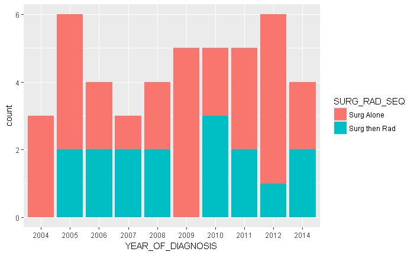

```r
data %>%
    ggplot(aes(x = YEAR_OF_DIAGNOSIS)) +
    geom_histogram(stat = "count", aes(fill = SURG_RAD_SEQ))
```

```
Ignoring unknown parameters: binwidth, bins, pad
```

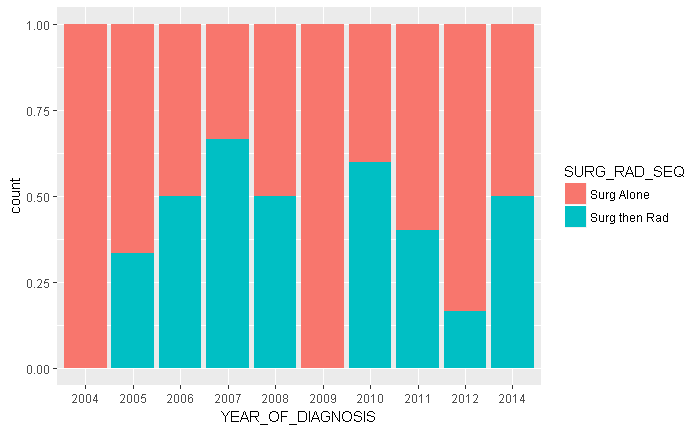

```r
data %>%
    ggplot(aes(x = YEAR_OF_DIAGNOSIS)) +
    geom_histogram(stat = "count", aes(fill = SURG_RAD_SEQ), position = "fill")
```

## Treatment by region

```r
p_table(data,
        vars = c("SURG_RAD_SEQ"),
        strata = c("FACILITY_LOCATION_F"))
```

```
|                 |     level     | New England | Middle Atlantic | South Atlantic | East North Central | East South Central | West North Central | West South Central | Mountain  | Pacific  |   p   | test |
|:----------------|:-------------:|:-----------:|:---------------:|:--------------:|:------------------:|:------------------:|:------------------:|:------------------:|:---------:|:--------:|:-----:|:----:|
|n                |               |      2      |        6        |       12       |         4          |         3          |         1          |         3          |     2     |    3     |       |      |
|SURG_RAD_SEQ (%) |  Surg Alone   |  2 (100.0)  |    2 (33.3)     |    6 (50.0)    |      3 (75.0)      |      2 (66.7)      |     1 (100.0)      |      2 (66.7)      | 2 (100.0) | 2 (66.7) | 0.625 |      |
|                 | Surg then Rad |  0 (  0.0)  |    4 (66.7)     |    6 (50.0)    |      1 (25.0)      |      1 (33.3)      |     0 (  0.0)      |      1 (33.3)      | 0 (  0.0) | 1 (33.3) |       |      |
```

## Treeatment by facility

### Number of cases by facility

```
Ignoring unknown parameters: binwidth, bins, pad
```

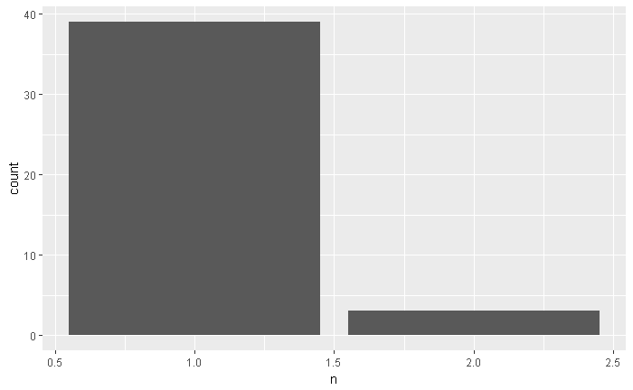

```r
data <- data %>%
        add_count(PUF_FACILITY_ID)

data %>%
        select(PUF_FACILITY_ID, n) %>%
        unique() %>%
        ggplot(aes(x = n)) +
        geom_histogram(stat = "count")
```

## Treatment by tumor size

```r
p_table(data,
        vars = c("SURG_RAD_SEQ"),
        strata = c("T_SIZE"))
```

```
|                 |     level     |  1-2 cm  |  2-3 cm  |  3-4 cm  |  4-5 cm  |  5-6 cm   |  >6 cm   |  NA_unk   |   p   | test |
|:----------------|:-------------:|:--------:|:--------:|:--------:|:--------:|:---------:|:--------:|:---------:|:-----:|:----:|
|n                |               |    3     |    2     |    4     |    4     |     3     |    7     |    22     |       |      |
|SURG_RAD_SEQ (%) |  Surg Alone   | 2 (66.7) | 1 (50.0) | 3 (75.0) | 2 (50.0) | 0 (  0.0) | 3 (42.9) | 18 (81.8) | 0.105 |      |
|                 | Surg then Rad | 1 (33.3) | 1 (50.0) | 1 (25.0) | 2 (50.0) | 3 (100.0) | 4 (57.1) | 4 (18.2)  |       |      |
```

```
Ignoring unknown parameters: binwidth, bins, pad
```

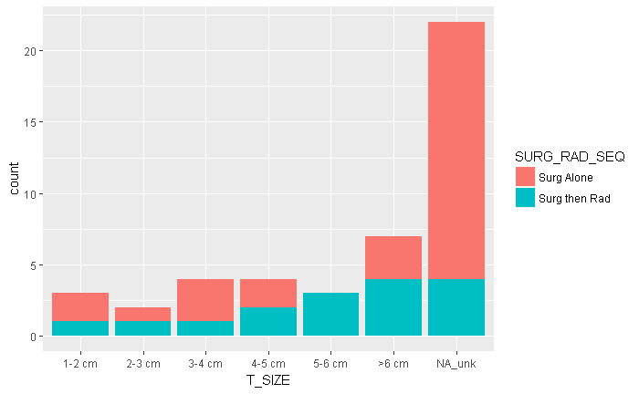

```r
data %>%
    ggplot(aes(x = T_SIZE)) +
    geom_histogram(stat = "count", aes(fill = SURG_RAD_SEQ))
```

```
Ignoring unknown parameters: binwidth, bins, pad
```

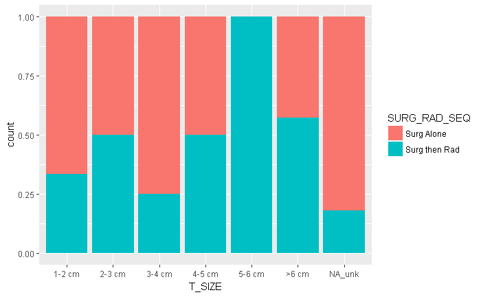

```r
data %>%
    ggplot(aes(x = T_SIZE)) +
    geom_histogram(stat = "count", aes(fill = SURG_RAD_SEQ), position = "fill")
```

# Tumor size by year

Limited to below 10 cm to exclude recording errors

```r
data <- data %>%
        mutate(TUMOR_SIZE_LIM = ifelse(TUMOR_SIZE < 100,
                                       TUMOR_SIZE,
                                        NA)) %>%
        mutate(T_SIZE_LIM = fct_recode(T_SIZE,
                                       NULL = "NA_unk"))
p_table(data,
        vars = c("TUMOR_SIZE", "TUMOR_SIZE_LIM", "T_SIZE_LIM"),
        strata = c("YEAR_OF_DIAGNOSIS"))
```

```
no non-missing arguments to min; returning Infno non-missing arguments to max; returning -InfVariable has only NA's in at least one stratum. na.rm turned off.
```

```
|                           | level  |      2004       |      2005       |      2006       |      2007       |      2008       |     2009      |      2010       |      2011       |      2012       |      2014       |   p   | test |
|:--------------------------|:------:|:---------------:|:---------------:|:---------------:|:---------------:|:---------------:|:-------------:|:---------------:|:---------------:|:---------------:|:---------------:|:-----:|:----:|
|n                          |        |        3        |        6        |        4        |        3        |        4        |       5       |        5        |        5        |        6        |        4        |       |      |
|TUMOR_SIZE (mean (sd))     |        | 348.00 (563.92) | 526.67 (517.79) | 535.75 (534.92) | 366.33 (547.91) | 769.25 (459.50) | 999.00 (0.00) | 221.20 (434.90) | 622.80 (515.20) | 372.00 (486.18) | 273.25 (484.08) | 0.317 |      |
|TUMOR_SIZE_LIM (mean (sd)) |        |  22.50 (17.68)  |  54.33 (31.09)  |  72.50 (3.54)   |  50.00 (0.00)   |   80.00 (NA)    |   NaN (NA)    |  26.75 (10.44)  |  58.50 (16.26)  |  58.50 (28.71)  |  31.33 (19.04)  |  NA   |      |
|T_SIZE_LIM (%)             | 1-2 cm |    1 (33.3)     |    0 ( 0.0)     |    0 ( 0.0)     |    0 ( 0.0)     |    0 ( 0.0)     |   0 (  0.0)   |    1 (20.0)     |    0 ( 0.0)     |    0 ( 0.0)     |    1 (25.0)     | 0.278 |      |
|                           | 2-3 cm |    0 ( 0.0)     |    0 ( 0.0)     |    0 ( 0.0)     |    0 ( 0.0)     |    0 ( 0.0)     |   0 (  0.0)   |    1 (20.0)     |    0 ( 0.0)     |    1 (16.7)     |    0 ( 0.0)     |       |      |
|                           | 3-4 cm |    1 (33.3)     |    1 (16.7)     |    0 ( 0.0)     |    0 ( 0.0)     |    0 ( 0.0)     |   0 (  0.0)   |    1 (20.0)     |    0 ( 0.0)     |    0 ( 0.0)     |    1 (25.0)     |       |      |
|                           | 4-5 cm |    0 ( 0.0)     |    1 (16.7)     |    0 ( 0.0)     |    0 ( 0.0)     |    0 ( 0.0)     |   0 (  0.0)   |    1 (20.0)     |    1 (20.0)     |    1 (16.7)     |    0 ( 0.0)     |       |      |
|                           | 5-6 cm |    0 ( 0.0)     |    0 ( 0.0)     |    0 ( 0.0)     |    2 (66.7)     |    0 ( 0.0)     |   0 (  0.0)   |    0 ( 0.0)     |    0 ( 0.0)     |    0 ( 0.0)     |    1 (25.0)     |       |      |
|                           | >6 cm  |    0 ( 0.0)     |    1 (16.7)     |    2 (50.0)     |    0 ( 0.0)     |    1 (25.0)     |   0 (  0.0)   |    0 ( 0.0)     |    1 (20.0)     |    2 (33.3)     |    0 ( 0.0)     |       |      |
|                           |   NA   |    1 (33.3)     |    3 (50.0)     |    2 (50.0)     |    1 (33.3)     |    3 (75.0)     |   5 (100.0)   |    1 (20.0)     |    3 (60.0)     |    2 (33.3)     |    1 (25.0)     |       |      |
```

```r
data %>%
        mutate(YEAR = as.numeric(as.character(YEAR_OF_DIAGNOSIS))) %>%
        lm(TUMOR_SIZE_LIM ~ YEAR,
              data = .) %>%
        summary()
```

```
Call:
lm(formula = TUMOR_SIZE_LIM ~ YEAR, data = .)

Residuals:
    Min      1Q  Median      3Q     Max
-40.732 -16.784  -5.136  22.416  39.967

Coefficients:
             Estimate Std. Error t value Pr(>|t|)
(Intercept) 1452.4774  3158.6758   0.460    0.650
YEAR          -0.6995     1.5722  -0.445    0.661

Residual standard error: 24.75 on 21 degrees of freedom
  (22 observations deleted due to missingness)
Multiple R-squared:  0.009338,  Adjusted R-squared:  -0.03784
F-statistic: 0.1979 on 1 and 21 DF,  p-value: 0.6609
```

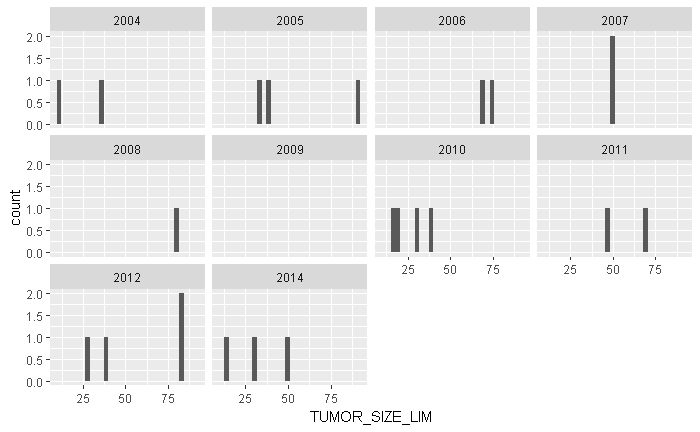

```r
data %>%
    ggplot(aes(x = TUMOR_SIZE_LIM)) +
    geom_histogram() +
    facet_wrap(~ YEAR_OF_DIAGNOSIS)
```

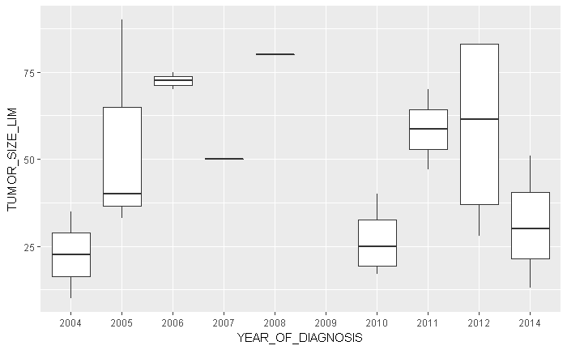

```r
data %>%
    ggplot(aes(x = YEAR_OF_DIAGNOSIS, y = TUMOR_SIZE_LIM)) +
    geom_boxplot()
```

```
Ignoring unknown parameters: binwidth, bins, pad
```

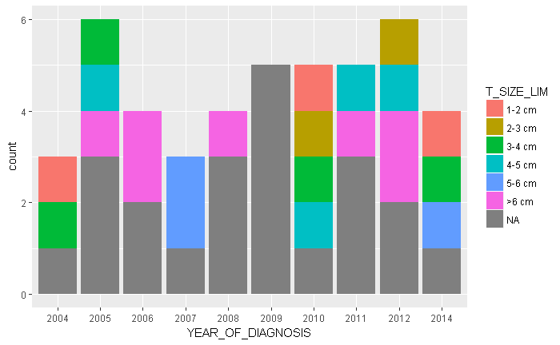

```r
data %>%
        ggplot(aes(x = YEAR_OF_DIAGNOSIS)) +
        geom_histogram(stat = "count",
                       aes(fill = T_SIZE_LIM))
```

```
Ignoring unknown parameters: binwidth, bins, pad
```

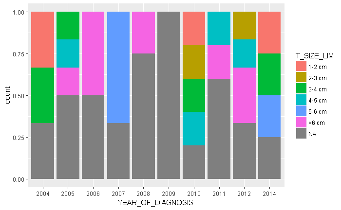

```r
data %>%
        ggplot(aes(x = YEAR_OF_DIAGNOSIS)) +
        geom_histogram(stat = "count",
                       aes(fill = T_SIZE_LIM),
                       position = "fill")
```

# Treatment models

```r
data <- data %>%
        mutate(FACILITY_LOCATION_F = fct_relevel(FACILITY_LOCATION_F,
                                             "Middle Atlantic")) %>%
        mutate(SURG_TX = case_when(SURGERY_YN == "Yes" ~ TRUE,
                                   SURGERY_YN == "No" ~ FALSE,
                                   TRUE ~ NA)) %>%
        mutate(YEAR_OF_DIAGNOSIS = fct_relevel(YEAR_OF_DIAGNOSIS,
                                               "2014"))
fit_surg <- glm(SURG_TX ~ AGE + SEX + CDCC_TOTAL + T_SIZE + FACILITY_TYPE_F + FACILITY_LOCATION_F +
                        YEAR_OF_DIAGNOSIS,
                family = "binomial",
                data = data)
summary(fit_surg)
```

```
Call:
glm(formula = SURG_TX ~ AGE + SEX + CDCC_TOTAL + T_SIZE + FACILITY_TYPE_F +
    FACILITY_LOCATION_F + YEAR_OF_DIAGNOSIS, family = "binomial",
    data = data)

Deviance Residuals:
      Min         1Q     Median         3Q        Max
3.971e-06  3.971e-06  3.971e-06  3.971e-06  3.971e-06

Coefficients:
                                               Estimate Std. Error z value Pr(>|z|)
(Intercept)                                   2.557e+01  6.782e+05       0        1
AGE                                          -4.491e-08  9.965e+03       0        1
SEX2                                         -2.857e-06  3.375e+05       0        1
CDCC_TOTAL1                                  -2.896e-06  3.229e+05       0        1
CDCC_TOTAL2                                   5.349e-07  4.551e+05       0        1
T_SIZE2-3 cm                                  1.915e-06  4.753e+05       0        1
T_SIZE3-4 cm                                  6.933e-06  6.031e+05       0        1
T_SIZE4-5 cm                                  3.301e-06  5.567e+05       0        1
T_SIZE5-6 cm                                  1.568e-06  3.714e+05       0        1
T_SIZE>6 cm                                   3.991e-06  5.780e+05       0        1
T_SIZENA_unk                                  2.966e-06  4.450e+05       0        1
FACILITY_TYPE_FAcademic/Research Program     -3.277e-06  2.812e+05       0        1
FACILITY_TYPE_FIntegrated Network Ca Program -8.201e-07  2.293e+05       0        1
FACILITY_LOCATION_FNew England                2.602e-07  4.808e+05       0        1
FACILITY_LOCATION_FSouth Atlantic            -4.013e-06  1.948e+05       0        1
FACILITY_LOCATION_FEast North Central        -1.764e-06  2.308e+05       0        1
FACILITY_LOCATION_FEast South Central        -2.246e-06  3.430e+05       0        1
FACILITY_LOCATION_FWest North Central         1.795e-06  6.134e+05       0        1
FACILITY_LOCATION_FWest South Central        -1.654e-06  3.050e+05       0        1
FACILITY_LOCATION_FMountain                   8.722e-07  4.713e+05       0        1
FACILITY_LOCATION_FPacific                    3.013e-06  5.696e+05       0        1
YEAR_OF_DIAGNOSIS2004                         1.289e-06  3.633e+05       0        1
YEAR_OF_DIAGNOSIS2005                        -1.095e-06  4.182e+05       0        1
YEAR_OF_DIAGNOSIS2006                        -1.971e-06  4.819e+05       0        1
YEAR_OF_DIAGNOSIS2007                         3.452e-06  2.798e+05       0        1
YEAR_OF_DIAGNOSIS2008                        -3.085e-06  5.224e+05       0        1
YEAR_OF_DIAGNOSIS2009                        -8.380e-07  2.972e+05       0        1
YEAR_OF_DIAGNOSIS2010                        -1.255e-06  4.063e+05       0        1
YEAR_OF_DIAGNOSIS2011                        -3.127e-06  6.026e+05       0        1
YEAR_OF_DIAGNOSIS2012                        -1.154e-06  4.304e+05       0        1

(Dispersion parameter for binomial family taken to be 1)

    Null deviance: 0.0000e+00  on 35  degrees of freedom
Residual deviance: 5.6772e-10  on  6  degrees of freedom
  (9 observations deleted due to missingness)
AIC: 60

Number of Fisher Scoring iterations: 24
```

```r
exp(cbind("Odds ratio" = coef(fit_surg), confint.default(fit_surg, level = 0.95)))
```

```
                                               Odds ratio 2.5 % 97.5 %
(Intercept)                                  1.268251e+11     0    Inf
AGE                                          1.000000e+00     0    Inf
SEX2                                         9.999971e-01     0    Inf
CDCC_TOTAL1                                  9.999971e-01     0    Inf
CDCC_TOTAL2                                  1.000001e+00     0    Inf
T_SIZE2-3 cm                                 1.000002e+00     0    Inf
T_SIZE3-4 cm                                 1.000007e+00     0    Inf
T_SIZE4-5 cm                                 1.000003e+00     0    Inf
T_SIZE5-6 cm                                 1.000002e+00     0    Inf
T_SIZE>6 cm                                  1.000004e+00     0    Inf
T_SIZENA_unk                                 1.000003e+00     0    Inf
FACILITY_TYPE_FAcademic/Research Program     9.999967e-01     0    Inf
FACILITY_TYPE_FIntegrated Network Ca Program 9.999992e-01     0    Inf
FACILITY_LOCATION_FNew England               1.000000e+00     0    Inf
FACILITY_LOCATION_FSouth Atlantic            9.999960e-01     0    Inf
FACILITY_LOCATION_FEast North Central        9.999982e-01     0    Inf
FACILITY_LOCATION_FEast South Central        9.999978e-01     0    Inf
FACILITY_LOCATION_FWest North Central        1.000002e+00     0    Inf
FACILITY_LOCATION_FWest South Central        9.999983e-01     0    Inf
FACILITY_LOCATION_FMountain                  1.000001e+00     0    Inf
FACILITY_LOCATION_FPacific                   1.000003e+00     0    Inf
YEAR_OF_DIAGNOSIS2004                        1.000001e+00     0    Inf
YEAR_OF_DIAGNOSIS2005                        9.999989e-01     0    Inf
YEAR_OF_DIAGNOSIS2006                        9.999980e-01     0    Inf
YEAR_OF_DIAGNOSIS2007                        1.000003e+00     0    Inf
YEAR_OF_DIAGNOSIS2008                        9.999969e-01     0    Inf
YEAR_OF_DIAGNOSIS2009                        9.999992e-01     0    Inf
YEAR_OF_DIAGNOSIS2010                        9.999987e-01     0    Inf
YEAR_OF_DIAGNOSIS2011                        9.999969e-01     0    Inf
YEAR_OF_DIAGNOSIS2012                        9.999988e-01     0    Inf
```

# no high-volume centers, so excluded the analyses specific for those centers

# Kaplan Meier Analysis

## All

```r
uni_var(test_var = "All", data_imp = data)
```

[output not shown]

```
_________________________________________________

## All
_________________________________________________
Call: survfit(formula = Surv(DX_LASTCONTACT_DEATH_MONTHS, PUF_VITAL_STATUS ==
    0) ~ All, data = data)

      n  events  median 0.95LCL 0.95UCL
     45       5      NA     113      NA

Call: survfit(formula = Surv(DX_LASTCONTACT_DEATH_MONTHS, PUF_VITAL_STATUS ==
    0) ~ All, data = data)

 time n.risk n.event survival std.err lower 95% CI upper 95% CI
   12     41       0    1.000  0.0000        1.000        1.000
   24     40       0    1.000  0.0000        1.000        1.000
   36     37       0    1.000  0.0000        1.000        1.000
   48     33       1    0.972  0.0274        0.920        1.000
   60     29       0    0.972  0.0274        0.920        1.000
  120      3       4    0.595  0.1573        0.355        0.999




## Univariable Cox Proportional Hazard Model for:  All

[1] "Only one level, no Cox model performed"





## Unadjusted Kaplan Meier Overall Survival Curve for:  All
```

## Facility Type

```
_________________________________________________

## FACILITY_TYPE_F
_________________________________________________
Call: survfit(formula = Surv(DX_LASTCONTACT_DEATH_MONTHS, PUF_VITAL_STATUS ==
    0) ~ FACILITY_TYPE_F, data = data)

   9 observations deleted due to missingness
                                               n events median 0.95LCL 0.95UCL
FACILITY_TYPE_F=Comprehensive Comm Ca Program  9      2  113.1    90.9      NA
FACILITY_TYPE_F=Academic/Research Program     24      1     NA   114.1      NA
FACILITY_TYPE_F=Integrated Network Ca Program  3      2   86.4    41.6      NA

Call: survfit(formula = Surv(DX_LASTCONTACT_DEATH_MONTHS, PUF_VITAL_STATUS ==
    0) ~ FACILITY_TYPE_F, data = data)

9 observations deleted due to missingness
                FACILITY_TYPE_F=Comprehensive Comm Ca Program
 time n.risk n.event survival std.err lower 95% CI upper 95% CI
   12      8       0        1       0            1            1
   24      8       0        1       0            1            1
   36      8       0        1       0            1            1
   48      7       0        1       0            1            1
   60      5       0        1       0            1            1

                FACILITY_TYPE_F=Academic/Research Program
 time n.risk n.event survival std.err lower 95% CI upper 95% CI
   12     21       0    1.000   0.000          1.0            1
   24     20       0    1.000   0.000          1.0            1
   36     18       0    1.000   0.000          1.0            1
   48     17       0    1.000   0.000          1.0            1
   60     15       0    1.000   0.000          1.0            1
  120      1       1    0.667   0.272          0.3            1

                FACILITY_TYPE_F=Integrated Network Ca Program
 time n.risk n.event survival std.err lower 95% CI upper 95% CI
   12      3       0    1.000   0.000       1.0000            1
   24      3       0    1.000   0.000       1.0000            1
   36      3       0    1.000   0.000       1.0000            1
   48      2       1    0.667   0.272       0.2995            1
```

[output cut: 14 more lines]

```
   (9 observations deleted due to missingness)

                                                coef exp(coef) se(coef)      z Pr(>|z|)
FACILITY_TYPE_FAcademic/Research Program     -1.3424    0.2612   1.2290 -1.092    0.275
FACILITY_TYPE_FIntegrated Network Ca Program  0.6328    1.8828   1.0150  0.623    0.533

                                             exp(coef) exp(-coef) lower .95 upper .95
FACILITY_TYPE_FAcademic/Research Program        0.2612     3.8283   0.02349     2.905
FACILITY_TYPE_FIntegrated Network Ca Program    1.8828     0.5311   0.25755    13.764

Concordance= 0.849  (se = 0.153 )
Rsquare= 0.08   (max possible= 0.464 )
Likelihood ratio test= 3.02  on 2 df,   p=0.2208
Wald test            = 2.57  on 2 df,   p=0.2768
Score (logrank) test = 3.24  on 2 df,   p=0.1975
```

```
Removed 1 rows containing missing values (geom_errorbar).
```

```
## Unadjusted Kaplan Meier Overall Survival Curve for:  FACILITY_TYPE_F
```

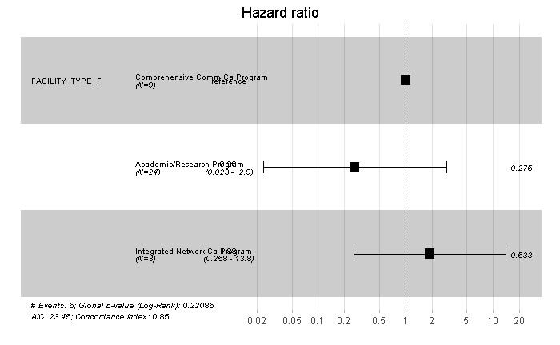

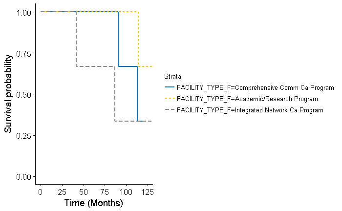

```r
uni_var(test_var = "FACILITY_TYPE_F", data_imp = data)
```

## Facility Location

```
_________________________________________________

## FACILITY_LOCATION_F
_________________________________________________
Call: survfit(formula = Surv(DX_LASTCONTACT_DEATH_MONTHS, PUF_VITAL_STATUS ==
    0) ~ FACILITY_LOCATION_F, data = data)

   9 observations deleted due to missingness
                                        n events median 0.95LCL 0.95UCL
FACILITY_LOCATION_F=Middle Atlantic     6      0     NA      NA      NA
FACILITY_LOCATION_F=New England         2      0     NA      NA      NA
FACILITY_LOCATION_F=South Atlantic     12      3     NA     113      NA
FACILITY_LOCATION_F=East North Central  4      1   86.4      NA      NA
FACILITY_LOCATION_F=East South Central  3      0     NA      NA      NA
FACILITY_LOCATION_F=West North Central  1      0     NA      NA      NA
FACILITY_LOCATION_F=West South Central  3      0     NA      NA      NA
FACILITY_LOCATION_F=Mountain            2      0     NA      NA      NA
FACILITY_LOCATION_F=Pacific             3      1  114.1      NA      NA

Call: survfit(formula = Surv(DX_LASTCONTACT_DEATH_MONTHS, PUF_VITAL_STATUS ==
    0) ~ FACILITY_LOCATION_F, data = data)

9 observations deleted due to missingness
                FACILITY_LOCATION_F=Middle Atlantic
 time n.risk n.event survival std.err lower 95% CI upper 95% CI
   12      6       0        1       0            1            1
   24      6       0        1       0            1            1
   36      6       0        1       0            1            1
   48      5       0        1       0            1            1
   60      4       0        1       0            1            1

                FACILITY_LOCATION_F=New England
 time n.risk n.event survival std.err lower 95% CI upper 95% CI
   12      1       0        1       0            1            1
   24      1       0        1       0            1            1
   36      1       0        1       0            1            1
   48      1       0        1       0            1            1
   60      1       0        1       0            1            1

                FACILITY_LOCATION_F=South Atlantic
```

[output cut: 42 more lines]

```
   48      1       0        1       0            1            1

                FACILITY_LOCATION_F=Pacific
 time n.risk n.event survival std.err lower 95% CI upper 95% CI
   12      3       0        1       0            1            1
   24      3       0        1       0            1            1
   36      3       0        1       0            1            1
   48      3       0        1       0            1            1
   60      2       0        1       0            1            1





## Univariable Cox Proportional Hazard Model for:  FACILITY_LOCATION_F
```

```
Loglik converged before variable  2,3,8 ; beta may be infinite. X matrix deemed to be singular; variable 5
```

```
Call:
coxph(formula = Surv(DX_LASTCONTACT_DEATH_MONTHS, PUF_VITAL_STATUS ==
    0) ~ FACILITY_LOCATION_F, data = data)

  n= 36, number of events= 5
   (9 observations deleted due to missingness)

                                            coef  exp(coef)   se(coef)     z Pr(>|z|)
FACILITY_LOCATION_FNew England         2.801e-01  1.323e+00  3.550e+04 0.000    1.000
FACILITY_LOCATION_FSouth Atlantic      1.956e+01  3.140e+08  2.994e+04 0.001    0.999
FACILITY_LOCATION_FEast North Central  2.124e+01  1.669e+09  2.994e+04 0.001    0.999
FACILITY_LOCATION_FEast South Central -1.019e+00  3.609e-01  1.295e+05 0.000    1.000
FACILITY_LOCATION_FWest North Central         NA         NA  0.000e+00    NA       NA
FACILITY_LOCATION_FWest South Central -1.019e+00  3.609e-01  1.807e+05 0.000    1.000
FACILITY_LOCATION_FMountain           -1.019e+00  3.609e-01  1.807e+05 0.000    1.000
FACILITY_LOCATION_FPacific             1.991e+01  4.443e+08  2.994e+04 0.001    0.999

                                      exp(coef) exp(-coef) lower .95 upper .95
FACILITY_LOCATION_FNew England        1.323e+00  7.557e-01         0       Inf
FACILITY_LOCATION_FSouth Atlantic     3.140e+08  3.185e-09         0       Inf
FACILITY_LOCATION_FEast North Central 1.669e+09  5.991e-10         0       Inf
FACILITY_LOCATION_FEast South Central 3.609e-01  2.771e+00         0       Inf
FACILITY_LOCATION_FWest North Central        NA         NA        NA        NA
FACILITY_LOCATION_FWest South Central 3.609e-01  2.771e+00         0       Inf
FACILITY_LOCATION_FMountain           3.609e-01  2.771e+00         0       Inf
FACILITY_LOCATION_FPacific            4.443e+08  2.251e-09         0       Inf

Concordance= 0.66  (se = 0.164 )
Rsquare= 0.102   (max possible= 0.464 )
Likelihood ratio test= 3.86  on 7 df,   p=0.7954
Wald test            = 1.32  on 7 df,   p=0.988
Score (logrank) test = 3.76  on 7 df,   p=0.807
```

```
Transformation introduced infinite values in continuous y-axisTransformation introduced infinite values in continuous y-axisTransformation introduced infinite values in continuous y-axisRemoved 2 rows containing missing values (geom_errorbar).Removed 9 rows containing missing values (geom_text).Remo…
```

```
## Unadjusted Kaplan Meier Overall Survival Curve for:  FACILITY_LOCATION_F
```

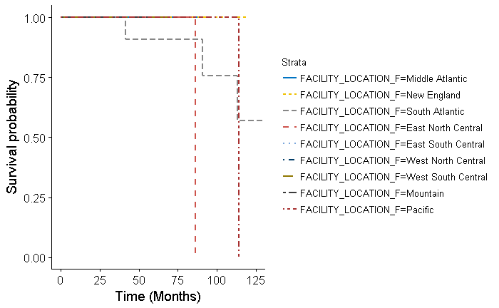

```r
uni_var(test_var = "FACILITY_LOCATION_F", data_imp = data)
```

## Facility Geography

```
_________________________________________________

## FACILITY_GEOGRAPHY
_________________________________________________
Call: survfit(formula = Surv(DX_LASTCONTACT_DEATH_MONTHS, PUF_VITAL_STATUS ==
    0) ~ FACILITY_GEOGRAPHY, data = data)

   9 observations deleted due to missingness
                              n events median 0.95LCL 0.95UCL
FACILITY_GEOGRAPHY=Northeast  8      0     NA      NA      NA
FACILITY_GEOGRAPHY=South     15      3     NA     113      NA
FACILITY_GEOGRAPHY=Midwest    8      1   86.4      NA      NA
FACILITY_GEOGRAPHY=West       5      1  114.1      NA      NA

Call: survfit(formula = Surv(DX_LASTCONTACT_DEATH_MONTHS, PUF_VITAL_STATUS ==
    0) ~ FACILITY_GEOGRAPHY, data = data)

9 observations deleted due to missingness
                FACILITY_GEOGRAPHY=Northeast
 time n.risk n.event survival std.err lower 95% CI upper 95% CI
   12      7       0        1       0            1            1
   24      7       0        1       0            1            1
   36      7       0        1       0            1            1
   48      6       0        1       0            1            1
   60      5       0        1       0            1            1

                FACILITY_GEOGRAPHY=South
 time n.risk n.event survival std.err lower 95% CI upper 95% CI
   12     13       0    1.000  0.0000        1.000            1
   24     13       0    1.000  0.0000        1.000            1
   36     12       0    1.000  0.0000        1.000            1
   48     11       1    0.917  0.0798        0.773            1
   60     11       0    0.917  0.0798        0.773            1
  120      2       2    0.573  0.2019        0.287            1

                FACILITY_GEOGRAPHY=Midwest
 time n.risk n.event survival std.err lower 95% CI upper 95% CI
   12      7       0        1       0            1            1
   24      7       0        1       0            1            1
   36      6       0        1       0            1            1
   48      5       0        1       0            1            1
   60      4       0        1       0            1            1

                FACILITY_GEOGRAPHY=West
 time n.risk n.event survival std.err lower 95% CI upper 95% CI
   12      5       0        1       0            1            1
   24      4       0        1       0            1            1
   36      4       0        1       0            1            1
   48      4       0        1       0            1            1
   60      2       0        1       0            1            1





## Univariable Cox Proportional Hazard Model for:  FACILITY_GEOGRAPHY
```

```
Loglik converged before variable  1,2,3 ; beta may be infinite.
```

```
Call:
coxph(formula = Surv(DX_LASTCONTACT_DEATH_MONTHS, PUF_VITAL_STATUS ==
    0) ~ FACILITY_GEOGRAPHY, data = data)

  n= 36, number of events= 5
   (9 observations deleted due to missingness)

                               coef exp(coef)  se(coef)     z Pr(>|z|)
FACILITY_GEOGRAPHYSouth   1.924e+01 2.280e+08 1.524e+04 0.001    0.999
FACILITY_GEOGRAPHYMidwest 2.078e+01 1.060e+09 1.524e+04 0.001    0.999
FACILITY_GEOGRAPHYWest    1.957e+01 3.168e+08 1.524e+04 0.001    0.999

                          exp(coef) exp(-coef) lower .95 upper .95
FACILITY_GEOGRAPHYSouth   2.280e+08  4.386e-09         0       Inf
FACILITY_GEOGRAPHYMidwest 1.060e+09  9.432e-10         0       Inf
FACILITY_GEOGRAPHYWest    3.168e+08  3.157e-09         0       Inf

Concordance= 0.594  (se = 0.162 )
Rsquare= 0.087   (max possible= 0.464 )
Likelihood ratio test= 3.26  on 3 df,   p=0.3532
Wald test            = 1.08  on 3 df,   p=0.7814
Score (logrank) test = 2.78  on 3 df,   p=0.4262
```

```
Transformation introduced infinite values in continuous y-axisTransformation introduced infinite values in continuous y-axisTransformation introduced infinite values in continuous y-axisRemoved 1 rows containing missing values (geom_errorbar).Removed 4 rows containing missing values (geom_text).Remo…
```

```
## Unadjusted Kaplan Meier Overall Survival Curve for:  FACILITY_GEOGRAPHY
```

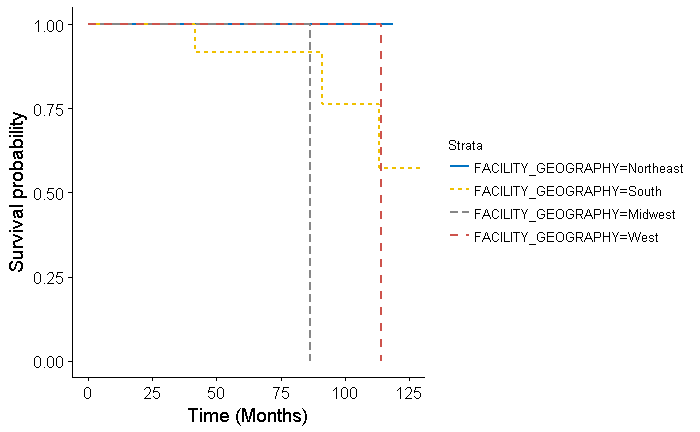

```r
uni_var(test_var = "FACILITY_GEOGRAPHY", data_imp = data)
```

## Age Group

```
_________________________________________________

## AGE_F
_________________________________________________
Call: survfit(formula = Surv(DX_LASTCONTACT_DEATH_MONTHS, PUF_VITAL_STATUS ==
    0) ~ AGE_F, data = data)

                n events median 0.95LCL 0.95UCL
AGE_F=(0,54]   19      0     NA      NA      NA
AGE_F=(54,64]   9      1     NA   113.1      NA
AGE_F=(64,74]  11      2   90.9    90.9      NA
AGE_F=(74,100]  6      2  114.1    86.4      NA

Call: survfit(formula = Surv(DX_LASTCONTACT_DEATH_MONTHS, PUF_VITAL_STATUS ==
    0) ~ AGE_F, data = data)

                AGE_F=(0,54]
 time n.risk n.event survival std.err lower 95% CI upper 95% CI
   12     19       0        1       0            1            1
   24     19       0        1       0            1            1
   36     18       0        1       0            1            1
   48     16       0        1       0            1            1
   60     13       0        1       0            1            1
  120      1       0        1       0            1            1

                AGE_F=(54,64]
 time n.risk n.event survival std.err lower 95% CI upper 95% CI
   12      7       0    1.000   0.000          1.0            1
   24      6       0    1.000   0.000          1.0            1
   36      5       0    1.000   0.000          1.0            1
   48      5       0    1.000   0.000          1.0            1
   60      5       0    1.000   0.000          1.0            1
  120      2       1    0.667   0.272          0.3            1

                AGE_F=(64,74]
 time n.risk n.event survival std.err lower 95% CI upper 95% CI
   12     10       0      1.0  0.0000        1.000            1
   24     10       0      1.0  0.0000        1.000            1
   36     10       0      1.0  0.0000        1.000            1
   48      8       1      0.9  0.0949        0.732            1
   60      8       0      0.9  0.0949        0.732            1

                AGE_F=(74,100]
 time n.risk n.event survival std.err lower 95% CI upper 95% CI
   12      5       0        1       0            1            1
   24      5       0        1       0            1            1
   36      4       0        1       0            1            1
   48      4       0        1       0            1            1
   60      3       0        1       0            1            1





## Univariable Cox Proportional Hazard Model for:  AGE_F
```

```
Loglik converged before variable  1,2,3 ; beta may be infinite.
```

```
Call:
coxph(formula = Surv(DX_LASTCONTACT_DEATH_MONTHS, PUF_VITAL_STATUS ==
    0) ~ AGE_F, data = data)

  n= 45, number of events= 5

                   coef exp(coef)  se(coef)     z Pr(>|z|)
AGE_F(54,64]  1.931e+01 2.441e+08 1.324e+04 0.001    0.999
AGE_F(64,74]  2.037e+01 7.047e+08 1.324e+04 0.002    0.999
AGE_F(74,100] 2.021e+01 6.014e+08 1.324e+04 0.002    0.999

              exp(coef) exp(-coef) lower .95 upper .95
AGE_F(54,64]  244062284  4.097e-09         0       Inf
AGE_F(64,74]  704669923  1.419e-09         0       Inf
AGE_F(74,100] 601368107  1.663e-09         0       Inf

Concordance= 0.81  (se = 0.159 )
Rsquare= 0.109   (max possible= 0.427 )
Likelihood ratio test= 5.21  on 3 df,   p=0.1569
Wald test            = 0.77  on 3 df,   p=0.8561
Score (logrank) test = 4.07  on 3 df,   p=0.2543
```

```
Transformation introduced infinite values in continuous y-axisTransformation introduced infinite values in continuous y-axisTransformation introduced infinite values in continuous y-axisRemoved 1 rows containing missing values (geom_errorbar).Removed 4 rows containing missing values (geom_text).Remo…
```

```
## Unadjusted Kaplan Meier Overall Survival Curve for:  AGE_F
```

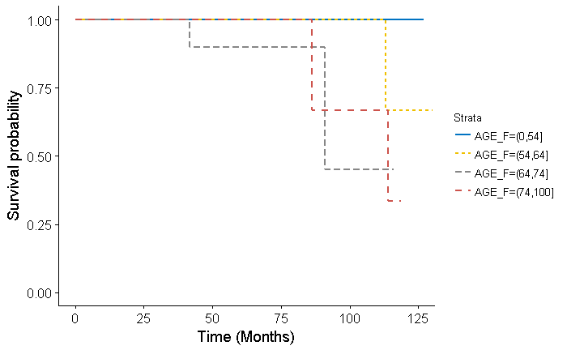

```r
uni_var(test_var = "AGE_F", data_imp = data)
```

## Age Group

```
_________________________________________________

## AGE_40
_________________________________________________
Call: survfit(formula = Surv(DX_LASTCONTACT_DEATH_MONTHS, PUF_VITAL_STATUS ==
    0) ~ AGE_40, data = data)

                 n events median 0.95LCL 0.95UCL
AGE_40=(0,40]    9      0     NA      NA      NA
AGE_40=(40,100] 36      5     NA     113      NA

Call: survfit(formula = Surv(DX_LASTCONTACT_DEATH_MONTHS, PUF_VITAL_STATUS ==
    0) ~ AGE_40, data = data)

                AGE_40=(0,40]
 time n.risk n.event survival std.err lower 95% CI upper 95% CI
   12      9       0        1       0            1            1
   24      9       0        1       0            1            1
   36      8       0        1       0            1            1
   48      7       0        1       0            1            1
   60      7       0        1       0            1            1
  120      1       0        1       0            1            1

                AGE_40=(40,100]
 time n.risk n.event survival std.err lower 95% CI upper 95% CI
   12     32       0    1.000  0.0000        1.000        1.000
   24     31       0    1.000  0.0000        1.000        1.000
   36     29       0    1.000  0.0000        1.000        1.000
   48     26       1    0.964  0.0351        0.898        1.000
   60     22       0    0.964  0.0351        0.898        1.000
  120      2       4    0.514  0.1703        0.269        0.984





## Univariable Cox Proportional Hazard Model for:  AGE_40
```

```
Loglik converged before variable  1 ; beta may be infinite.
```

```
Call:
coxph(formula = Surv(DX_LASTCONTACT_DEATH_MONTHS, PUF_VITAL_STATUS ==
    0) ~ AGE_40, data = data)

  n= 45, number of events= 5

                    coef exp(coef)  se(coef)     z Pr(>|z|)
AGE_40(40,100] 1.946e+01 2.821e+08 1.373e+04 0.001    0.999

               exp(coef) exp(-coef) lower .95 upper .95
AGE_40(40,100] 282138222  3.544e-09         0       Inf

Concordance= 0.627  (se = 0.124 )
Rsquare= 0.056   (max possible= 0.427 )
Likelihood ratio test= 2.58  on 1 df,   p=0.108
Wald test            = 0  on 1 df,   p=0.9989
Score (logrank) test = 1.49  on 1 df,   p=0.2227
```

[output not shown]

```
## Unadjusted Kaplan Meier Overall Survival Curve for:  AGE_40
```

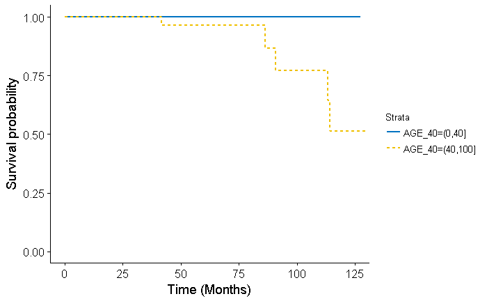

```r
uni_var(test_var = "AGE_40", data_imp = data)
```

## Gender

```
_________________________________________________

## SEX_F
_________________________________________________
Call: survfit(formula = Surv(DX_LASTCONTACT_DEATH_MONTHS, PUF_VITAL_STATUS ==
    0) ~ SEX_F, data = data)

              n events median 0.95LCL 0.95UCL
SEX_F=Male   20      1     NA      NA      NA
SEX_F=Female 25      4    114     113      NA

Call: survfit(formula = Surv(DX_LASTCONTACT_DEATH_MONTHS, PUF_VITAL_STATUS ==
    0) ~ SEX_F, data = data)

                SEX_F=Male
 time n.risk n.event survival std.err lower 95% CI upper 95% CI
   12     18       0    1.000   0.000        1.000            1
   24     18       0    1.000   0.000        1.000            1
   36     16       0    1.000   0.000        1.000            1
   48     15       0    1.000   0.000        1.000            1
   60     13       0    1.000   0.000        1.000            1
  120      1       1    0.833   0.152        0.583            1

                SEX_F=Female
 time n.risk n.event survival std.err lower 95% CI upper 95% CI
   12     23       0    1.000  0.0000        1.000            1
   24     22       0    1.000  0.0000        1.000            1
   36     21       0    1.000  0.0000        1.000            1
   48     18       1    0.952  0.0465        0.866            1
   60     16       0    0.952  0.0465        0.866            1
  120      2       3    0.500  0.1959        0.232            1





## Univariable Cox Proportional Hazard Model for:  SEX_F

Call:
coxph(formula = Surv(DX_LASTCONTACT_DEATH_MONTHS, PUF_VITAL_STATUS ==
    0) ~ SEX_F, data = data)

  n= 45, number of events= 5

              coef exp(coef) se(coef)     z Pr(>|z|)
SEX_FFemale 0.9325    2.5409   1.1246 0.829    0.407

            exp(coef) exp(-coef) lower .95 upper .95
SEX_FFemale     2.541     0.3936    0.2804     23.03

Concordance= 0.627  (se = 0.145 )
Rsquare= 0.018   (max possible= 0.427 )
Likelihood ratio test= 0.81  on 1 df,   p=0.3686
Wald test            = 0.69  on 1 df,   p=0.407
Score (logrank) test = 0.74  on 1 df,   p=0.3906
```

```
Removed 1 rows containing missing values (geom_errorbar).
```

```
## Unadjusted Kaplan Meier Overall Survival Curve for:  SEX_F
```

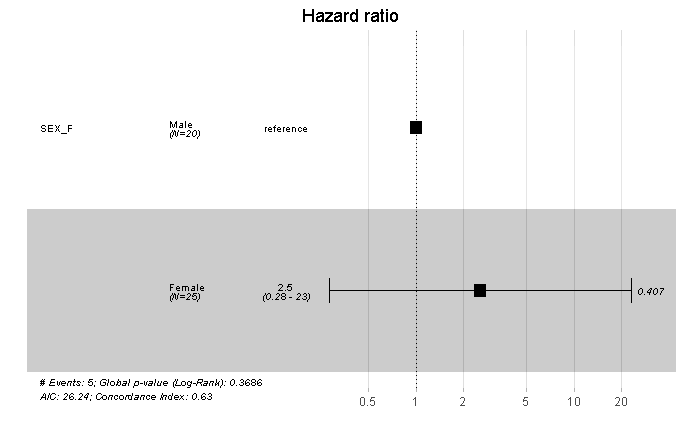

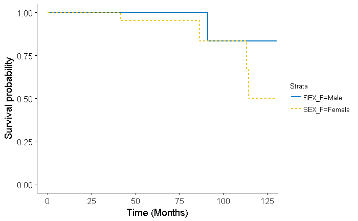

```r
uni_var(test_var = "SEX_F", data_imp = data)
```

## RACE_F

```
_________________________________________________

## RACE_F
_________________________________________________
Call: survfit(formula = Surv(DX_LASTCONTACT_DEATH_MONTHS, PUF_VITAL_STATUS ==
    0) ~ RACE_F, data = data)

              n events median 0.95LCL 0.95UCL
RACE_F=White 37      4     NA     113      NA
RACE_F=Black  6      1     NA      NA      NA
RACE_F=Asian  2      0     NA      NA      NA

Call: survfit(formula = Surv(DX_LASTCONTACT_DEATH_MONTHS, PUF_VITAL_STATUS ==
    0) ~ RACE_F, data = data)

                RACE_F=White
 time n.risk n.event survival std.err lower 95% CI upper 95% CI
   12     34       0    1.000   0.000        1.000            1
   24     33       0    1.000   0.000        1.000            1
   36     30       0    1.000   0.000        1.000            1
   48     27       0    1.000   0.000        1.000            1
   60     24       0    1.000   0.000        1.000            1
  120      3       4    0.556   0.176        0.299            1

                RACE_F=Black
 time n.risk n.event survival std.err lower 95% CI upper 95% CI
   12      6       0    1.000   0.000        1.000            1
   24      6       0    1.000   0.000        1.000            1
   36      6       0    1.000   0.000        1.000            1
   48      5       1    0.833   0.152        0.583            1
   60      4       0    0.833   0.152        0.583            1

                RACE_F=Asian
 time n.risk n.event survival std.err lower 95% CI upper 95% CI
   12      1       0        1       0            1            1
   24      1       0        1       0            1            1
   36      1       0        1       0            1            1
   48      1       0        1       0            1            1
   60      1       0        1       0            1            1





## Univariable Cox Proportional Hazard Model for:  RACE_F
```

```
Loglik converged before variable  2 ; beta may be infinite.
```

```
Call:
coxph(formula = Surv(DX_LASTCONTACT_DEATH_MONTHS, PUF_VITAL_STATUS ==
    0) ~ RACE_F, data = data)

  n= 45, number of events= 5

                  coef  exp(coef)   se(coef)      z Pr(>|z|)
RACE_FBlack  3.059e-01  1.358e+00  1.119e+00  0.273    0.785
RACE_FAsian -1.599e+01  1.132e-07  1.811e+04 -0.001    0.999

            exp(coef) exp(-coef) lower .95 upper .95
RACE_FBlack 1.358e+00  7.364e-01    0.1516     12.17
RACE_FAsian 1.132e-07  8.833e+06    0.0000       Inf

Concordance= 0.669  (se = 0.114 )
Rsquare= 0.003   (max possible= 0.427 )
Likelihood ratio test= 0.13  on 2 df,   p=0.9387
Wald test            = 0.07  on 2 df,   p=0.9633
Score (logrank) test = 0.1  on 2 df,   p=0.9491
```

[output not shown]

```
## Unadjusted Kaplan Meier Overall Survival Curve for:  RACE_F
```

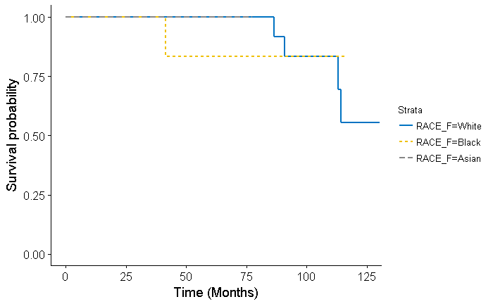

```r
uni_var(test_var = "RACE_F", data_imp = data)
```

## Hispanic

```
_________________________________________________

## HISPANIC
_________________________________________________
Call: survfit(formula = Surv(DX_LASTCONTACT_DEATH_MONTHS, PUF_VITAL_STATUS ==
    0) ~ HISPANIC, data = data)

                  n events median 0.95LCL 0.95UCL
HISPANIC=No      39      3     NA   113.1      NA
HISPANIC=Yes      2      0     NA      NA      NA
HISPANIC=Unknown  4      2    114    86.4      NA

Call: survfit(formula = Surv(DX_LASTCONTACT_DEATH_MONTHS, PUF_VITAL_STATUS ==
    0) ~ HISPANIC, data = data)

                HISPANIC=No
 time n.risk n.event survival std.err lower 95% CI upper 95% CI
   12     35       0    1.000  0.0000        1.000            1
   24     35       0    1.000  0.0000        1.000            1
   36     32       0    1.000  0.0000        1.000            1
   48     28       1    0.968  0.0317        0.908            1
   60     24       0    0.968  0.0317        0.908            1
  120      3       2    0.697  0.1738        0.427            1

                HISPANIC=Yes
 time n.risk n.event survival std.err lower 95% CI upper 95% CI
   12      2       0        1       0            1            1
   24      1       0        1       0            1            1
   36      1       0        1       0            1            1
   48      1       0        1       0            1            1
   60      1       0        1       0            1            1

                HISPANIC=Unknown
 time n.risk n.event survival std.err lower 95% CI upper 95% CI
   12      4       0        1       0            1            1
   24      4       0        1       0            1            1
   36      4       0        1       0            1            1
   48      4       0        1       0            1            1
   60      4       0        1       0            1            1





## Univariable Cox Proportional Hazard Model for:  HISPANIC
```

```
Loglik converged before variable  1 ; beta may be infinite.
```

```
Call:
coxph(formula = Surv(DX_LASTCONTACT_DEATH_MONTHS, PUF_VITAL_STATUS ==
    0) ~ HISPANIC, data = data)

  n= 45, number of events= 5

                      coef  exp(coef)   se(coef)      z Pr(>|z|)
HISPANICYes     -1.699e+01  4.189e-08  1.257e+04 -0.001    0.999
HISPANICUnknown  8.626e-01  2.369e+00  9.373e-01  0.920    0.357

                exp(coef) exp(-coef) lower .95 upper .95
HISPANICYes     4.189e-08  2.387e+07    0.0000       Inf
HISPANICUnknown 2.369e+00  4.221e-01    0.3774     14.87

Concordance= 0.563  (se = 0.11 )
Rsquare= 0.025   (max possible= 0.427 )
Likelihood ratio test= 1.15  on 2 df,   p=0.5623
Wald test            = 0.85  on 2 df,   p=0.6547
Score (logrank) test = 1.11  on 2 df,   p=0.5733
```

[output not shown]

```
## Unadjusted Kaplan Meier Overall Survival Curve for:  HISPANIC
```

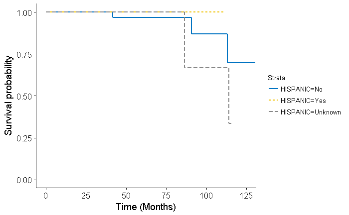

```r
uni_var(test_var = "HISPANIC", data_imp = data)
```

## Insurance Status

```
_________________________________________________

## INSURANCE_F
_________________________________________________
Call: survfit(formula = Surv(DX_LASTCONTACT_DEATH_MONTHS, PUF_VITAL_STATUS ==
    0) ~ INSURANCE_F, data = data)

                              n events median 0.95LCL 0.95UCL
INSURANCE_F=Private          26      1     NA      NA      NA
INSURANCE_F=Medicaid          1      0     NA      NA      NA
INSURANCE_F=Medicare         16      4   90.9    86.4      NA
INSURANCE_F=Other Government  1      0     NA      NA      NA
INSURANCE_F=Unknown           1      0     NA      NA      NA

Call: survfit(formula = Surv(DX_LASTCONTACT_DEATH_MONTHS, PUF_VITAL_STATUS ==
    0) ~ INSURANCE_F, data = data)

                INSURANCE_F=Private
 time n.risk n.event survival std.err lower 95% CI upper 95% CI
   12     24       0    1.000   0.000        1.000            1
   24     24       0    1.000   0.000        1.000            1
   36     22       0    1.000   0.000        1.000            1
   48     20       0    1.000   0.000        1.000            1
   60     18       0    1.000   0.000        1.000            1
  120      3       1    0.833   0.152        0.583            1

                INSURANCE_F=Medicaid
 time n.risk n.event survival std.err lower 95% CI upper 95% CI
   12      1       0        1       0            1            1
   24      1       0        1       0            1            1
   36      1       0        1       0            1            1
   48      1       0        1       0            1            1

                INSURANCE_F=Medicare
 time n.risk n.event survival std.err lower 95% CI upper 95% CI
   12     14       0    1.000  0.0000        1.000            1
   24     13       0    1.000  0.0000        1.000            1
   36     12       0    1.000  0.0000        1.000            1
   48     10       1    0.917  0.0798        0.773            1
   60      9       0    0.917  0.0798        0.773            1

                INSURANCE_F=Other Government
 time n.risk n.event survival std.err lower 95% CI upper 95% CI
   12      1       0        1       0            1            1
   24      1       0        1       0            1            1
   36      1       0        1       0            1            1
   48      1       0        1       0            1            1
   60      1       0        1       0            1            1

                INSURANCE_F=Unknown
 time n.risk n.event survival std.err lower 95% CI upper 95% CI
   12      1       0        1       0            1            1
   24      1       0        1       0            1            1
   36      1       0        1       0            1            1
   48      1       0        1       0            1            1
   60      1       0        1       0            1            1





## Univariable Cox Proportional Hazard Model for:  INSURANCE_F
```

```
Loglik converged before variable  1,3,4 ; beta may be infinite.
```

```
Call:
coxph(formula = Surv(DX_LASTCONTACT_DEATH_MONTHS, PUF_VITAL_STATUS ==
    0) ~ INSURANCE_F, data = data)

  n= 45, number of events= 5

                                  coef  exp(coef)   se(coef)      z Pr(>|z|)
INSURANCE_FMedicaid         -1.676e+01  5.237e-08  6.451e+04  0.000   0.9998
INSURANCE_FMedicare          2.798e+00  1.641e+01  1.131e+00  2.473   0.0134 *
INSURANCE_FOther Government -1.676e+01  5.237e-08  6.451e+04  0.000   0.9998
INSURANCE_FUnknown          -1.727e+01  3.162e-08  2.656e+04 -0.001   0.9995
---
Signif. codes:  0 *** 0.001 ** 0.01 * 0.05 . 0.1   1

                            exp(coef) exp(-coef) lower .95 upper .95
INSURANCE_FMedicaid         5.237e-08  1.909e+07     0.000       Inf
INSURANCE_FMedicare         1.641e+01  6.094e-02     1.787     150.7
INSURANCE_FOther Government 5.237e-08  1.909e+07     0.000       Inf
INSURANCE_FUnknown          3.162e-08  3.163e+07     0.000       Inf

Concordance= 0.852  (se = 0.143 )
Rsquare= 0.175   (max possible= 0.427 )
Likelihood ratio test= 8.64  on 4 df,   p=0.07071
Wald test            = 6.12  on 4 df,   p=0.1906
Score (logrank) test = 11.44  on 4 df,   p=0.02208
```

[output not shown]

```
## Unadjusted Kaplan Meier Overall Survival Curve for:  INSURANCE_F
```

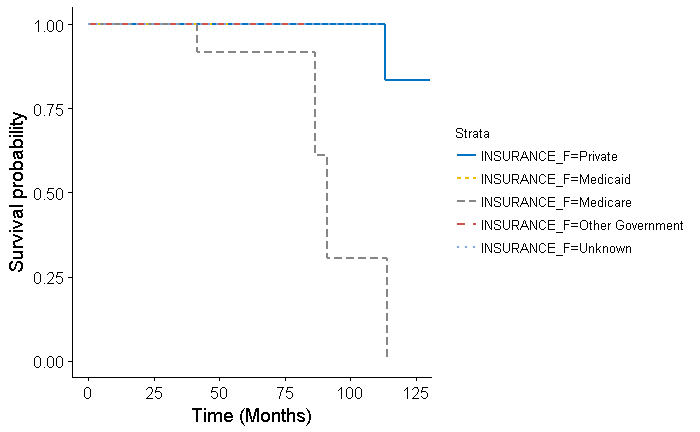

```r
uni_var(test_var = "INSURANCE_F", data_imp = data)
```

## Income

```r
uni_var(test_var = "INCOME_F", data_imp = data)
```

```
_________________________________________________

## INCOME_F
_________________________________________________
Call: survfit(formula = Surv(DX_LASTCONTACT_DEATH_MONTHS, PUF_VITAL_STATUS ==
    0) ~ INCOME_F, data = data)

   2 observations deleted due to missingness
                            n events median 0.95LCL 0.95UCL
INCOME_F=Less than $38,000  7      2  113.1    86.4      NA
INCOME_F=$38,000 - $47,999 11      2   90.9    90.9      NA
INCOME_F=$48,000 - $62,999 12      1     NA   114.1      NA
INCOME_F=$63,000 +         13      0     NA      NA      NA

Call: survfit(formula = Surv(DX_LASTCONTACT_DEATH_MONTHS, PUF_VITAL_STATUS ==
    0) ~ INCOME_F, data = data)

2 observations deleted due to missingness
                INCOME_F=Less than $38,000
 time n.risk n.event survival std.err lower 95% CI upper 95% CI
   12      7       0        1       0            1            1
   24      6       0        1       0            1            1
   36      5       0        1       0            1            1
   48      5       0        1       0            1            1
   60      5       0        1       0            1            1

                INCOME_F=$38,000 - $47,999
 time n.risk n.event survival std.err lower 95% CI upper 95% CI
   12      9       0    1.000   0.000        1.000            1
   24      9       0    1.000   0.000        1.000            1
   36      9       0    1.000   0.000        1.000            1
   48      7       1    0.889   0.105        0.706            1
   60      6       0    0.889   0.105        0.706            1
  120      1       1    0.444   0.319        0.109            1

                INCOME_F=$48,000 - $62,999
 time n.risk n.event survival std.err lower 95% CI upper 95% CI
   12     12       0     1.00   0.000        1.000            1
   24     12       0     1.00   0.000        1.000            1
   36     11       0     1.00   0.000        1.000            1
   48     11       0     1.00   0.000        1.000            1
   60      9       0     1.00   0.000        1.000            1
  120      2       1     0.75   0.217        0.426            1

                INCOME_F=$63,000 +
 time n.risk n.event survival std.err lower 95% CI upper 95% CI
   12     11       0        1       0            1            1
   24     11       0        1       0            1            1
   36     10       0        1       0            1            1
   48      8       0        1       0            1            1
   60      8       0        1       0            1            1





## Univariable Cox Proportional Hazard Model for:  INCOME_F
```

```
Loglik converged before variable  3 ; beta may be infinite.
```

```
Call:
coxph(formula = Surv(DX_LASTCONTACT_DEATH_MONTHS, PUF_VITAL_STATUS ==
    0) ~ INCOME_F, data = data)

  n= 43, number of events= 5
   (2 observations deleted due to missingness)

                                coef  exp(coef)   se(coef)      z Pr(>|z|)
INCOME_F$38,000 - $47,999 -4.206e-01  6.567e-01  1.079e+00 -0.390   0.6968
INCOME_F$48,000 - $62,999 -2.220e+00  1.086e-01  1.325e+00 -1.676   0.0937 .
INCOME_F$63,000 +         -2.092e+01  8.219e-10  1.865e+04 -0.001   0.9991
---
Signif. codes:  0 *** 0.001 ** 0.01 * 0.05 . 0.1   1

                          exp(coef) exp(-coef) lower .95 upper .95
INCOME_F$38,000 - $47,999 6.567e-01  1.523e+00  0.079176     5.446
INCOME_F$48,000 - $62,999 1.086e-01  9.210e+00  0.008097     1.456
INCOME_F$63,000 +         8.219e-10  1.217e+09  0.000000       Inf

Concordance= 0.783  (se = 0.16 )
Rsquare= 0.135   (max possible= 0.44 )
Likelihood ratio test= 6.22  on 3 df,   p=0.1015
Wald test            = 3.04  on 3 df,   p=0.3852
Score (logrank) test = 6.27  on 3 df,   p=0.09924
```

[output not shown]

```
## Unadjusted Kaplan Meier Overall Survival Curve for:  INCOME_F
```

[output not shown]

## Education

```
_________________________________________________

## EDUCATION_F
_________________________________________________
Call: survfit(formula = Surv(DX_LASTCONTACT_DEATH_MONTHS, PUF_VITAL_STATUS ==
    0) ~ EDUCATION_F, data = data)

   2 observations deleted due to missingness
                          n events median 0.95LCL 0.95UCL
EDUCATION_F=21% or more  10      2     NA     113      NA
EDUCATION_F=13 - 20.9%    5      0     NA      NA      NA
EDUCATION_F=7 - 12.9%    17      3     NA     114      NA
EDUCATION_F=Less than 7% 11      0     NA      NA      NA

Call: survfit(formula = Surv(DX_LASTCONTACT_DEATH_MONTHS, PUF_VITAL_STATUS ==
    0) ~ EDUCATION_F, data = data)

2 observations deleted due to missingness
                EDUCATION_F=21% or more
 time n.risk n.event survival std.err lower 95% CI upper 95% CI
   12      9       0    1.000   0.000        1.000            1
   24      8       0    1.000   0.000        1.000            1
   36      8       0    1.000   0.000        1.000            1
   48      8       0    1.000   0.000        1.000            1
   60      7       0    1.000   0.000        1.000            1
  120      1       2    0.533   0.248        0.214            1

                EDUCATION_F=13 - 20.9%
 time n.risk n.event survival std.err lower 95% CI upper 95% CI
   12      4       0        1       0            1            1
   24      4       0        1       0            1            1
   36      3       0        1       0            1            1
   48      2       0        1       0            1            1
   60      1       0        1       0            1            1

                EDUCATION_F=7 - 12.9%
 time n.risk n.event survival std.err lower 95% CI upper 95% CI
   12     16       0    1.000  0.0000        1.000            1
   24     16       0    1.000  0.0000        1.000            1
   36     15       0    1.000  0.0000        1.000            1
   48     14       1    0.933  0.0644        0.815            1
   60     13       0    0.933  0.0644        0.815            1
  120      2       2    0.533  0.2357        0.224            1

                EDUCATION_F=Less than 7%
 time n.risk n.event survival std.err lower 95% CI upper 95% CI
   12     10       0        1       0            1            1
   24     10       0        1       0            1            1
   36      9       0        1       0            1            1
   48      7       0        1       0            1            1
   60      7       0        1       0            1            1





## Univariable Cox Proportional Hazard Model for:  EDUCATION_F
```

```
Loglik converged before variable  1,3 ; beta may be infinite.
```

```
Call:
coxph(formula = Surv(DX_LASTCONTACT_DEATH_MONTHS, PUF_VITAL_STATUS ==
    0) ~ EDUCATION_F, data = data)

  n= 43, number of events= 5
   (2 observations deleted due to missingness)

                              coef  exp(coef)   se(coef)      z Pr(>|z|)
EDUCATION_F13 - 20.9%   -1.960e+01  3.077e-09  5.030e+04  0.000    1.000
EDUCATION_F7 - 12.9%     2.366e-02  1.024e+00  9.183e-01  0.026    0.979
EDUCATION_FLess than 7% -1.936e+01  3.921e-09  1.560e+04 -0.001    0.999

                        exp(coef) exp(-coef) lower .95 upper .95
EDUCATION_F13 - 20.9%   3.077e-09  3.250e+08    0.0000       Inf
EDUCATION_F7 - 12.9%    1.024e+00  9.766e-01    0.1693     6.193
EDUCATION_FLess than 7% 3.921e-09  2.550e+08    0.0000       Inf

Concordance= 0.652  (se = 0.156 )
Rsquare= 0.048   (max possible= 0.44 )
Likelihood ratio test= 2.1  on 3 df,   p=0.5524
Wald test            = 0  on 3 df,   p=1
Score (logrank) test = 1.18  on 3 df,   p=0.7572
```

[output not shown]

```
## Unadjusted Kaplan Meier Overall Survival Curve for:  EDUCATION_F
```

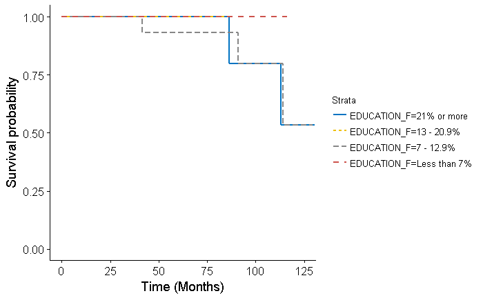

```r
uni_var(test_var = "EDUCATION_F", data_imp = data)
```

## Urban/Rural

```
_________________________________________________

## U_R_F
_________________________________________________
Call: survfit(formula = Surv(DX_LASTCONTACT_DEATH_MONTHS, PUF_VITAL_STATUS ==
    0) ~ U_R_F, data = data)

   3 observations deleted due to missingness
             n events median 0.95LCL 0.95UCL
U_R_F=Metro 38      3     NA      NA      NA
U_R_F=Urban  3      1    114      NA      NA
U_R_F=Rural  1      1    113      NA      NA

Call: survfit(formula = Surv(DX_LASTCONTACT_DEATH_MONTHS, PUF_VITAL_STATUS ==
    0) ~ U_R_F, data = data)

3 observations deleted due to missingness
                U_R_F=Metro
 time n.risk n.event survival std.err lower 95% CI upper 95% CI
   12     34       0    1.000  0.0000        1.000            1
   24     33       0    1.000  0.0000        1.000            1
   36     30       0    1.000  0.0000        1.000            1
   48     26       1    0.966  0.0339        0.901            1
   60     23       0    0.966  0.0339        0.901            1
  120      3       2    0.790  0.1157        0.593            1

                U_R_F=Urban
 time n.risk n.event survival std.err lower 95% CI upper 95% CI
   12      3       0        1       0            1            1
   24      3       0        1       0            1            1
   36      3       0        1       0            1            1
   48      3       0        1       0            1            1
   60      2       0        1       0            1            1

                U_R_F=Rural
 time n.risk n.event survival std.err lower 95% CI upper 95% CI
   12      1       0        1       0            1            1
   24      1       0        1       0            1            1
   36      1       0        1       0            1            1
   48      1       0        1       0            1            1
```

[output cut: 13 more lines]

```
   (3 observations deleted due to missingness)

             coef exp(coef) se(coef)     z Pr(>|z|)
U_R_FUrban 0.7962    2.2171   1.1747 0.678    0.498
U_R_FRural 1.4272    4.1672   1.2227 1.167    0.243

           exp(coef) exp(-coef) lower .95 upper .95
U_R_FUrban     2.217      0.451    0.2218     22.16
U_R_FRural     4.167      0.240    0.3794     45.77

Concordance= 0.508  (se = 0.102 )
Rsquare= 0.031   (max possible= 0.434 )
Likelihood ratio test= 1.33  on 2 df,   p=0.5132
Wald test            = 1.54  on 2 df,   p=0.4629
Score (logrank) test = 1.73  on 2 df,   p=0.4206
```

```
Removed 1 rows containing missing values (geom_errorbar).
```

```
## Unadjusted Kaplan Meier Overall Survival Curve for:  U_R_F
```

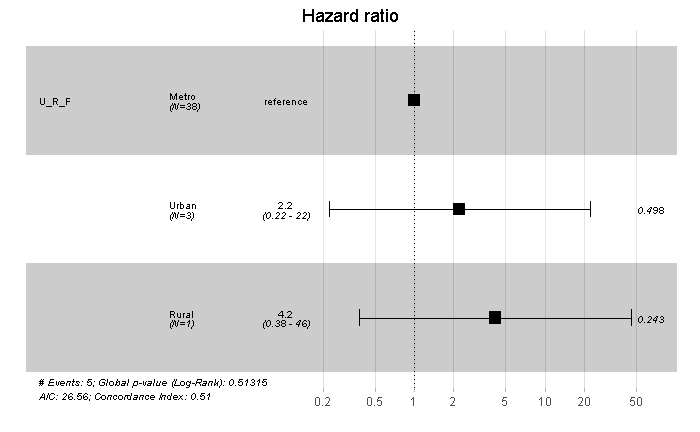

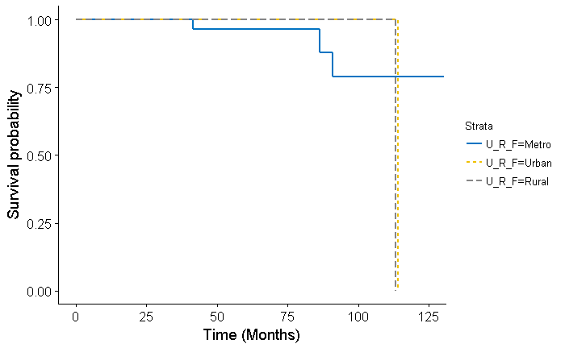

```r
uni_var(test_var = "U_R_F", data_imp = data)
```

## Comorbidities

```
_________________________________________________

## CDCC_TOTAL
_________________________________________________
Call: survfit(formula = Surv(DX_LASTCONTACT_DEATH_MONTHS, PUF_VITAL_STATUS ==
    0) ~ CDCC_TOTAL, data = data)

              n events median 0.95LCL 0.95UCL
CDCC_TOTAL=0 35      3     NA   113.1      NA
CDCC_TOTAL=1  9      2    103    90.9      NA
CDCC_TOTAL=2  1      0     NA      NA      NA

Call: survfit(formula = Surv(DX_LASTCONTACT_DEATH_MONTHS, PUF_VITAL_STATUS ==
    0) ~ CDCC_TOTAL, data = data)

                CDCC_TOTAL=0
 time n.risk n.event survival std.err lower 95% CI upper 95% CI
   12     33       0    1.000  0.0000        1.000            1
   24     32       0    1.000  0.0000        1.000            1
   36     30       0    1.000  0.0000        1.000            1
   48     27       1    0.967  0.0328        0.905            1
   60     25       0    0.967  0.0328        0.905            1
  120      3       2    0.738  0.1514        0.494            1

                CDCC_TOTAL=1
 time n.risk n.event survival std.err lower 95% CI upper 95% CI
   12      8       0        1       0            1            1
   24      8       0        1       0            1            1
   36      7       0        1       0            1            1
   48      6       0        1       0            1            1
   60      4       0        1       0            1            1

                CDCC_TOTAL=2
     time n.risk n.event survival std.err lower 95% CI upper 95% CI





## Univariable Cox Proportional Hazard Model for:  CDCC_TOTAL
```

```
X matrix deemed to be singular; variable 2
```

```
Call:
coxph(formula = Surv(DX_LASTCONTACT_DEATH_MONTHS, PUF_VITAL_STATUS ==
    0) ~ CDCC_TOTAL, data = data)

  n= 45, number of events= 5

              coef exp(coef) se(coef)     z Pr(>|z|)
CDCC_TOTAL1 1.2953    3.6521   0.9136 1.418    0.156
CDCC_TOTAL2     NA        NA   0.0000    NA       NA

            exp(coef) exp(-coef) lower .95 upper .95
CDCC_TOTAL1     3.652     0.2738    0.6094     21.89
CDCC_TOTAL2        NA         NA        NA        NA

Concordance= 0.549  (se = 0.108 )
Rsquare= 0.038   (max possible= 0.427 )
Likelihood ratio test= 1.75  on 1 df,   p=0.1862
Wald test            = 2.01  on 1 df,   p=0.1562
Score (logrank) test = 2.31  on 1 df,   p=0.1288
```

```
Removed 2 rows containing missing values (geom_errorbar).
```

```
## Unadjusted Kaplan Meier Overall Survival Curve for:  CDCC_TOTAL
```

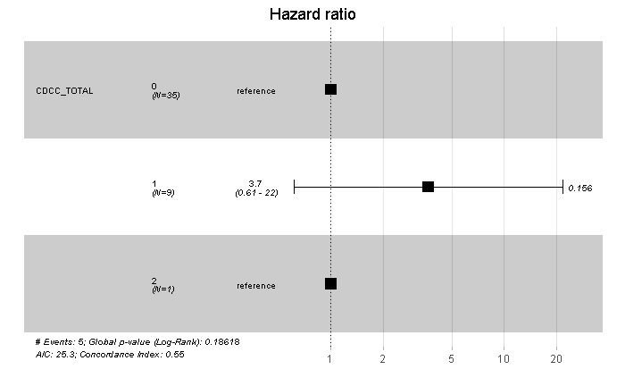

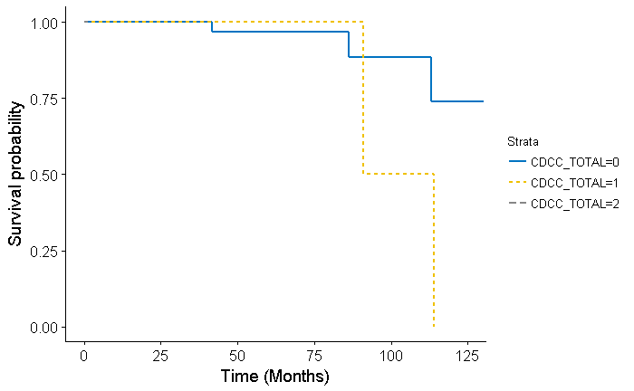

```r
uni_var(test_var = "CDCC_TOTAL", data_imp = data)
```

## Class (treatment at performing facility)

```
_________________________________________________

## CLASS_OF_CASE_F
_________________________________________________
Call: survfit(formula = Surv(DX_LASTCONTACT_DEATH_MONTHS, PUF_VITAL_STATUS ==
    0) ~ CLASS_OF_CASE_F, data = data)

                                n events median 0.95LCL 0.95UCL
CLASS_OF_CASE_F=Other_Facility  1      0     NA      NA      NA
CLASS_OF_CASE_F=All_Part_Prim  44      5     NA     113      NA

Call: survfit(formula = Surv(DX_LASTCONTACT_DEATH_MONTHS, PUF_VITAL_STATUS ==
    0) ~ CLASS_OF_CASE_F, data = data)

                CLASS_OF_CASE_F=Other_Facility
 time n.risk n.event survival std.err lower 95% CI upper 95% CI
   12      1       0        1       0            1            1
   24      1       0        1       0            1            1
   36      1       0        1       0            1            1
   48      1       0        1       0            1            1
   60      1       0        1       0            1            1

                CLASS_OF_CASE_F=All_Part_Prim
 time n.risk n.event survival std.err lower 95% CI upper 95% CI
   12     40       0    1.000  0.0000        1.000        1.000
   24     39       0    1.000  0.0000        1.000        1.000
   36     36       0    1.000  0.0000        1.000        1.000
   48     32       1    0.971  0.0282        0.918        1.000
   60     28       0    0.971  0.0282        0.918        1.000
  120      3       4    0.595  0.1572        0.354        0.999





## Univariable Cox Proportional Hazard Model for:  CLASS_OF_CASE_F
```

```
Loglik converged before variable  1 ; beta may be infinite.
```

```
Call:
coxph(formula = Surv(DX_LASTCONTACT_DEATH_MONTHS, PUF_VITAL_STATUS ==
    0) ~ CLASS_OF_CASE_F, data = data)

  n= 45, number of events= 5

                                  coef exp(coef)  se(coef)     z Pr(>|z|)
CLASS_OF_CASE_FAll_Part_Prim 1.604e+01 9.292e+06 1.803e+04 0.001    0.999

                             exp(coef) exp(-coef) lower .95 upper .95
CLASS_OF_CASE_FAll_Part_Prim   9291971  1.076e-07         0       Inf

Concordance= 0.507  (se = 0.042 )
Rsquare= 0.001   (max possible= 0.427 )
Likelihood ratio test= 0.06  on 1 df,   p=0.8124
Wald test            = 0  on 1 df,   p=0.9993
Score (logrank) test = 0.03  on 1 df,   p=0.8658
```

[output not shown]

```
## Unadjusted Kaplan Meier Overall Survival Curve for:  CLASS_OF_CASE_F
```

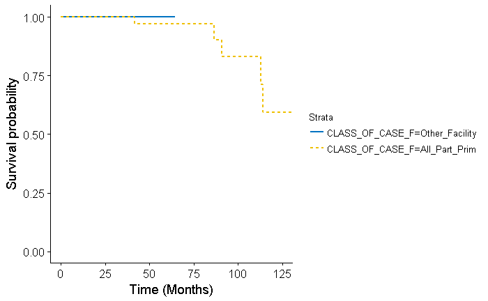

```r
uni_var(test_var = "CLASS_OF_CASE_F", data_imp = data)
```

## Year

```
_________________________________________________

## YEAR_OF_DIAGNOSIS
_________________________________________________
Call: survfit(formula = Surv(DX_LASTCONTACT_DEATH_MONTHS, PUF_VITAL_STATUS ==
    0) ~ YEAR_OF_DIAGNOSIS, data = data)

                       n events median 0.95LCL 0.95UCL
YEAR_OF_DIAGNOSIS=2014 4      0     NA      NA      NA
YEAR_OF_DIAGNOSIS=2004 3      0     NA      NA      NA
YEAR_OF_DIAGNOSIS=2005 6      3  114.1    86.4      NA
YEAR_OF_DIAGNOSIS=2006 4      1     NA   113.1      NA
YEAR_OF_DIAGNOSIS=2007 3      0     NA      NA      NA
YEAR_OF_DIAGNOSIS=2008 4      0     NA      NA      NA
YEAR_OF_DIAGNOSIS=2009 5      1   90.9      NA      NA
YEAR_OF_DIAGNOSIS=2010 5      0     NA      NA      NA
YEAR_OF_DIAGNOSIS=2011 5      0     NA      NA      NA
YEAR_OF_DIAGNOSIS=2012 6      0     NA      NA      NA

Call: survfit(formula = Surv(DX_LASTCONTACT_DEATH_MONTHS, PUF_VITAL_STATUS ==
    0) ~ YEAR_OF_DIAGNOSIS, data = data)

                YEAR_OF_DIAGNOSIS=2014
 time n.risk n.event survival std.err lower 95% CI upper 95% CI
   12      3       0        1       0            1            1
   24      3       0        1       0            1            1

                YEAR_OF_DIAGNOSIS=2004
 time n.risk n.event survival std.err lower 95% CI upper 95% CI
   12      2       0        1       0            1            1
   24      2       0        1       0            1            1
   36      2       0        1       0            1            1
   48      2       0        1       0            1            1
   60      2       0        1       0            1            1
  120      1       0        1       0            1            1

                YEAR_OF_DIAGNOSIS=2005
 time n.risk n.event survival std.err lower 95% CI upper 95% CI
   12      6       0    1.000   0.000       1.0000            1
   24      6       0    1.000   0.000       1.0000            1
```

[output cut: 51 more lines]

```
   48      4       0        1       0            1            1
   60      1       0        1       0            1            1

                YEAR_OF_DIAGNOSIS=2012
 time n.risk n.event survival std.err lower 95% CI upper 95% CI
   12      4       0        1       0            1            1
   24      3       0        1       0            1            1
   36      3       0        1       0            1            1
   48      1       0        1       0            1            1





## Univariable Cox Proportional Hazard Model for:  YEAR_OF_DIAGNOSIS
```

```
Loglik converged before variable  2,3,6,7,8 ; beta may be infinite. X matrix deemed to be singular; variable 9
```

```
Call:
coxph(formula = Surv(DX_LASTCONTACT_DEATH_MONTHS, PUF_VITAL_STATUS ==
    0) ~ YEAR_OF_DIAGNOSIS, data = data)

  n= 45, number of events= 5

                           coef exp(coef)  se(coef)  z Pr(>|z|)
YEAR_OF_DIAGNOSIS2004 5.424e-01 1.720e+00 1.037e+05  0        1
YEAR_OF_DIAGNOSIS2005 2.104e+01 1.374e+09 1.005e+05  0        1
YEAR_OF_DIAGNOSIS2006 1.982e+01 4.058e+08 1.005e+05  0        1
YEAR_OF_DIAGNOSIS2007 5.005e-01 1.650e+00 1.030e+05  0        1
YEAR_OF_DIAGNOSIS2008 2.942e-01 1.342e+00 1.058e+05  0        1
YEAR_OF_DIAGNOSIS2009 2.145e+01 2.063e+09 1.005e+05  0        1
YEAR_OF_DIAGNOSIS2010 3.145e-06 1.000e+00 1.189e+05  0        1
YEAR_OF_DIAGNOSIS2011 3.264e-06 1.000e+00 1.189e+05  0        1
YEAR_OF_DIAGNOSIS2012        NA        NA 0.000e+00 NA       NA

                      exp(coef) exp(-coef) lower .95 upper .95
YEAR_OF_DIAGNOSIS2004 1.720e+00  5.814e-01         0       Inf
YEAR_OF_DIAGNOSIS2005 1.374e+09  7.278e-10         0       Inf
YEAR_OF_DIAGNOSIS2006 4.058e+08  2.464e-09         0       Inf
YEAR_OF_DIAGNOSIS2007 1.650e+00  6.062e-01         0       Inf
YEAR_OF_DIAGNOSIS2008 1.342e+00  7.451e-01         0       Inf
YEAR_OF_DIAGNOSIS2009 2.063e+09  4.847e-10         0       Inf
YEAR_OF_DIAGNOSIS2010 1.000e+00  1.000e+00         0       Inf
YEAR_OF_DIAGNOSIS2011 1.000e+00  1.000e+00         0       Inf
YEAR_OF_DIAGNOSIS2012        NA         NA        NA        NA

Concordance= 0.81  (se = 0.168 )
Rsquare= 0.139   (max possible= 0.427 )
Likelihood ratio test= 6.75  on 8 df,   p=0.5636
Wald test            = 1.39  on 8 df,   p=0.9944
Score (logrank) test = 6.09  on 8 df,   p=0.6369
```

[output not shown]

```
## Unadjusted Kaplan Meier Overall Survival Curve for:  YEAR_OF_DIAGNOSIS
```

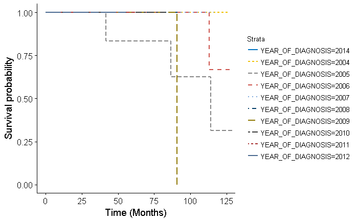

```r
uni_var(test_var = "YEAR_OF_DIAGNOSIS", data_imp = data)
```

## Primary Site

```r
#uni_var(test_var = "SITE_TEXT", data_imp = data)
```

## Histology

```
_________________________________________________

## HISTOLOGY_F_LIM
_________________________________________________
Call: survfit(formula = Surv(DX_LASTCONTACT_DEATH_MONTHS, PUF_VITAL_STATUS ==
    0) ~ HISTOLOGY_F_LIM, data = data)

                      n events median 0.95LCL 0.95UCL
HISTOLOGY_F_LIM=9150 36      3     NA   114.1      NA
HISTOLOGY_F_LIM=8815  9      2    113    86.4      NA

Call: survfit(formula = Surv(DX_LASTCONTACT_DEATH_MONTHS, PUF_VITAL_STATUS ==
    0) ~ HISTOLOGY_F_LIM, data = data)

                HISTOLOGY_F_LIM=9150
 time n.risk n.event survival std.err lower 95% CI upper 95% CI
   12     33       0    1.000  0.0000        1.000            1
   24     32       0    1.000  0.0000        1.000            1
   36     29       0    1.000  0.0000        1.000            1
   48     26       1    0.966  0.0339        0.901            1
   60     23       0    0.966  0.0339        0.901            1
  120      3       2    0.731  0.1528        0.486            1

                HISTOLOGY_F_LIM=8815
 time n.risk n.event survival std.err lower 95% CI upper 95% CI
   12      8       0        1       0            1            1
   24      8       0        1       0            1            1
   36      8       0        1       0            1            1
   48      7       0        1       0            1            1
   60      6       0        1       0            1            1





## Univariable Cox Proportional Hazard Model for:  HISTOLOGY_F_LIM

Call:
coxph(formula = Surv(DX_LASTCONTACT_DEATH_MONTHS, PUF_VITAL_STATUS ==
    0) ~ HISTOLOGY_F_LIM, data = data)

  n= 45, number of events= 5

                     coef exp(coef) se(coef)     z Pr(>|z|)
HISTOLOGY_F_LIM8815 1.554     4.732    1.005 1.547    0.122

                    exp(coef) exp(-coef) lower .95 upper .95
HISTOLOGY_F_LIM8815     4.732     0.2113      0.66     33.93

Concordance= 0.556  (se = 0.114 )
Rsquare= 0.047   (max possible= 0.427 )
Likelihood ratio test= 2.19  on 1 df,   p=0.139
Wald test            = 2.39  on 1 df,   p=0.122
Score (logrank) test = 2.9  on 1 df,   p=0.08851
```

```
Removed 1 rows containing missing values (geom_errorbar).
```

```
## Unadjusted Kaplan Meier Overall Survival Curve for:  HISTOLOGY_F_LIM
```

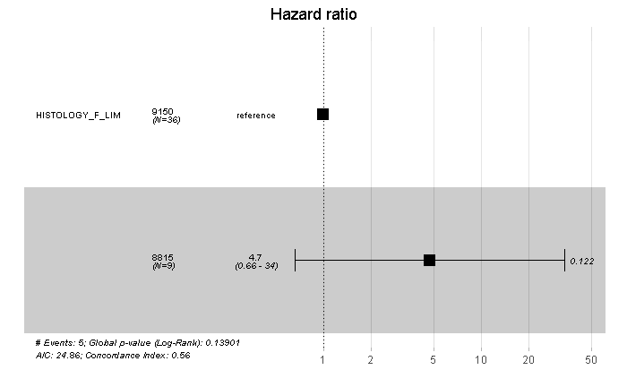

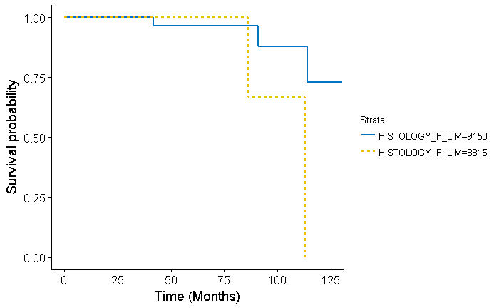

```r
uni_var(test_var = "HISTOLOGY_F_LIM", data_imp = data)
```

## Behavior

```r
uni_var(test_var = "BEHAVIOR", data_imp = data)
```

```
_________________________________________________

## BEHAVIOR
_________________________________________________
Call: survfit(formula = Surv(DX_LASTCONTACT_DEATH_MONTHS, PUF_VITAL_STATUS ==
    0) ~ BEHAVIOR, data = data)

      n  events  median 0.95LCL 0.95UCL
     45       5      NA     113      NA

Call: survfit(formula = Surv(DX_LASTCONTACT_DEATH_MONTHS, PUF_VITAL_STATUS ==
    0) ~ BEHAVIOR, data = data)

 time n.risk n.event survival std.err lower 95% CI upper 95% CI
   12     41       0    1.000  0.0000        1.000        1.000
   24     40       0    1.000  0.0000        1.000        1.000
   36     37       0    1.000  0.0000        1.000        1.000
   48     33       1    0.972  0.0274        0.920        1.000
   60     29       0    0.972  0.0274        0.920        1.000
  120      3       4    0.595  0.1573        0.355        0.999




## Univariable Cox Proportional Hazard Model for:  BEHAVIOR

[1] "Only one level, no Cox model performed"





## Unadjusted Kaplan Meier Overall Survival Curve for:  BEHAVIOR
```

## Grade

```
_________________________________________________

## GRADE_F
_________________________________________________
Call: survfit(formula = Surv(DX_LASTCONTACT_DEATH_MONTHS, PUF_VITAL_STATUS ==
    0) ~ GRADE_F, data = data)

                                  n events median 0.95LCL 0.95UCL
GRADE_F=Gr I: Well Diff           1      0     NA      NA      NA
GRADE_F=Gr II: Mod Diff           2      0     NA      NA      NA
GRADE_F=Gr III: Poor Diff         3      1    113      NA      NA
GRADE_F=Gr IV: Undiff/Anaplastic  1      0     NA      NA      NA
GRADE_F=NA/Unkown                38      4     NA     114      NA

Call: survfit(formula = Surv(DX_LASTCONTACT_DEATH_MONTHS, PUF_VITAL_STATUS ==
    0) ~ GRADE_F, data = data)

                GRADE_F=Gr I: Well Diff
 time n.risk n.event survival std.err lower 95% CI upper 95% CI
   12      1       0        1       0            1            1
   24      1       0        1       0            1            1
   36      1       0        1       0            1            1
   48      1       0        1       0            1            1
   60      1       0        1       0            1            1
  120      1       0        1       0            1            1

                GRADE_F=Gr II: Mod Diff
 time n.risk n.event survival std.err lower 95% CI upper 95% CI
   12      2       0        1       0            1            1
   24      2       0        1       0            1            1
   36      1       0        1       0            1            1
   48      1       0        1       0            1            1
   60      1       0        1       0            1            1

                GRADE_F=Gr III: Poor Diff
 time n.risk n.event survival std.err lower 95% CI upper 95% CI
   12      3       0        1       0            1            1
   24      3       0        1       0            1            1
   36      2       0        1       0            1            1
   48      2       0        1       0            1            1
```

[output cut: 9 more lines]

```

                GRADE_F=NA/Unkown
 time n.risk n.event survival std.err lower 95% CI upper 95% CI
   12     34       0    1.000  0.0000        1.000            1
   24     33       0    1.000  0.0000        1.000            1
   36     32       0    1.000  0.0000        1.000            1
   48     28       1    0.968  0.0317        0.908            1
   60     24       0    0.968  0.0317        0.908            1
  120      2       3    0.645  0.1679        0.387            1





## Univariable Cox Proportional Hazard Model for:  GRADE_F
```

```
Loglik converged before variable  1,2,3,4 ; beta may be infinite.
```

```
Call:
coxph(formula = Surv(DX_LASTCONTACT_DEATH_MONTHS, PUF_VITAL_STATUS ==
    0) ~ GRADE_F, data = data)

  n= 45, number of events= 5

                                      coef  exp(coef)   se(coef)     z Pr(>|z|)
GRADE_FGr II: Mod Diff          -1.846e-03  9.982e-01  5.793e+04 0.000    1.000
GRADE_FGr III: Poor Diff         1.942e+01  2.725e+08  1.323e+04 0.001    0.999
GRADE_FGr IV: Undiff/Anaplastic -1.846e-03  9.982e-01  5.793e+04 0.000    1.000
GRADE_FNA/Unkown                 1.826e+01  8.484e+07  1.323e+04 0.001    0.999

                                exp(coef) exp(-coef) lower .95 upper .95
GRADE_FGr II: Mod Diff          9.982e-01  1.002e+00         0       Inf
GRADE_FGr III: Poor Diff        2.725e+08  3.669e-09         0       Inf
GRADE_FGr IV: Undiff/Anaplastic 9.982e-01  1.002e+00         0       Inf
GRADE_FNA/Unkown                8.484e+07  1.179e-08         0       Inf

Concordance= 0.556  (se = 0.104 )
Rsquare= 0.043   (max possible= 0.427 )
Likelihood ratio test= 1.96  on 4 df,   p=0.7436
Wald test            = 0.98  on 4 df,   p=0.9124
Score (logrank) test = 1.83  on 4 df,   p=0.7675
```

[output not shown]

```
## Unadjusted Kaplan Meier Overall Survival Curve for:  GRADE_F
```

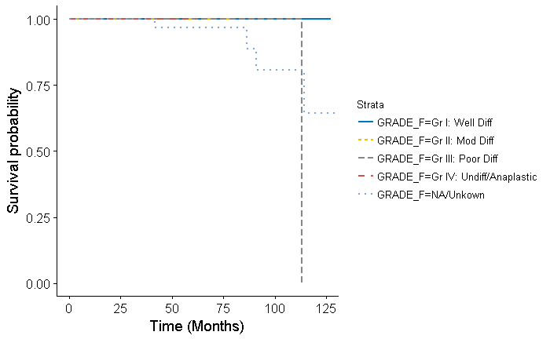

```r
uni_var(test_var = "GRADE_F", data_imp = data)
```

## Clinical T Stage

```r
uni_var(test_var = "TNM_CLIN_T", data_imp = data)
```

```
_________________________________________________

## TNM_CLIN_T
_________________________________________________
Call: survfit(formula = Surv(DX_LASTCONTACT_DEATH_MONTHS, PUF_VITAL_STATUS ==
    0) ~ TNM_CLIN_T, data = data)

   1 observation deleted due to missingness
      n  events  median 0.95LCL 0.95UCL
     44       5      NA     113      NA

Call: survfit(formula = Surv(DX_LASTCONTACT_DEATH_MONTHS, PUF_VITAL_STATUS ==
    0) ~ TNM_CLIN_T, data = data)

1 observation deleted due to missingness
 time n.risk n.event survival std.err lower 95% CI upper 95% CI
   12     41       0    1.000  0.0000        1.000        1.000
   24     40       0    1.000  0.0000        1.000        1.000
   36     37       0    1.000  0.0000        1.000        1.000
   48     33       1    0.972  0.0274        0.920        1.000
   60     29       0    0.972  0.0274        0.920        1.000
  120      3       4    0.595  0.1573        0.355        0.999




## Univariable Cox Proportional Hazard Model for:  TNM_CLIN_T

[1] "Only one level, no Cox model performed"





## Unadjusted Kaplan Meier Overall Survival Curve for:  TNM_CLIN_T
```

## Clinical N Stage

```r
uni_var(test_var = "TNM_CLIN_N", data_imp = data)
```

```
_________________________________________________

## TNM_CLIN_N
_________________________________________________
Call: survfit(formula = Surv(DX_LASTCONTACT_DEATH_MONTHS, PUF_VITAL_STATUS ==
    0) ~ TNM_CLIN_N, data = data)

   1 observation deleted due to missingness
      n  events  median 0.95LCL 0.95UCL
     44       5      NA     113      NA

Call: survfit(formula = Surv(DX_LASTCONTACT_DEATH_MONTHS, PUF_VITAL_STATUS ==
    0) ~ TNM_CLIN_N, data = data)

1 observation deleted due to missingness
 time n.risk n.event survival std.err lower 95% CI upper 95% CI
   12     41       0    1.000  0.0000        1.000        1.000
   24     40       0    1.000  0.0000        1.000        1.000
   36     37       0    1.000  0.0000        1.000        1.000
   48     33       1    0.972  0.0274        0.920        1.000
   60     29       0    0.972  0.0274        0.920        1.000
  120      3       4    0.595  0.1573        0.355        0.999




## Univariable Cox Proportional Hazard Model for:  TNM_CLIN_N

[1] "Only one level, no Cox model performed"





## Unadjusted Kaplan Meier Overall Survival Curve for:  TNM_CLIN_N
```

## Clinical M Stage

```r
uni_var(test_var = "TNM_CLIN_M", data_imp = data)
```

```
_________________________________________________

## TNM_CLIN_M
_________________________________________________
Call: survfit(formula = Surv(DX_LASTCONTACT_DEATH_MONTHS, PUF_VITAL_STATUS ==
    0) ~ TNM_CLIN_M, data = data)

   1 observation deleted due to missingness
      n  events  median 0.95LCL 0.95UCL
     44       5      NA     113      NA

Call: survfit(formula = Surv(DX_LASTCONTACT_DEATH_MONTHS, PUF_VITAL_STATUS ==
    0) ~ TNM_CLIN_M, data = data)

1 observation deleted due to missingness
 time n.risk n.event survival std.err lower 95% CI upper 95% CI
   12     41       0    1.000  0.0000        1.000        1.000
   24     40       0    1.000  0.0000        1.000        1.000
   36     37       0    1.000  0.0000        1.000        1.000
   48     33       1    0.972  0.0274        0.920        1.000
   60     29       0    0.972  0.0274        0.920        1.000
  120      3       4    0.595  0.1573        0.355        0.999




## Univariable Cox Proportional Hazard Model for:  TNM_CLIN_M

[1] "Only one level, no Cox model performed"





## Unadjusted Kaplan Meier Overall Survival Curve for:  TNM_CLIN_M
```

## Clinical Stage Group

```r
uni_var(test_var = "TNM_CLIN_STAGE_GROUP", data_imp = data)
```

```
_________________________________________________

## TNM_CLIN_STAGE_GROUP
_________________________________________________
Call: survfit(formula = Surv(DX_LASTCONTACT_DEATH_MONTHS, PUF_VITAL_STATUS ==
    0) ~ TNM_CLIN_STAGE_GROUP, data = data)

      n  events  median 0.95LCL 0.95UCL
     45       5      NA     113      NA

Call: survfit(formula = Surv(DX_LASTCONTACT_DEATH_MONTHS, PUF_VITAL_STATUS ==
    0) ~ TNM_CLIN_STAGE_GROUP, data = data)

 time n.risk n.event survival std.err lower 95% CI upper 95% CI
   12     41       0    1.000  0.0000        1.000        1.000
   24     40       0    1.000  0.0000        1.000        1.000
   36     37       0    1.000  0.0000        1.000        1.000
   48     33       1    0.972  0.0274        0.920        1.000
   60     29       0    0.972  0.0274        0.920        1.000
  120      3       4    0.595  0.1573        0.355        0.999




## Univariable Cox Proportional Hazard Model for:  TNM_CLIN_STAGE_GROUP

[1] "Only one level, no Cox model performed"





## Unadjusted Kaplan Meier Overall Survival Curve for:  TNM_CLIN_STAGE_GROUP
```

## Pathologic T Stage

```r
uni_var(test_var = "TNM_PATH_T", data_imp = data)
```

```
_________________________________________________

## TNM_PATH_T
_________________________________________________
Call: survfit(formula = Surv(DX_LASTCONTACT_DEATH_MONTHS, PUF_VITAL_STATUS ==
    0) ~ TNM_PATH_T, data = data)

   1 observation deleted due to missingness
      n  events  median 0.95LCL 0.95UCL
     44       5      NA     113      NA

Call: survfit(formula = Surv(DX_LASTCONTACT_DEATH_MONTHS, PUF_VITAL_STATUS ==
    0) ~ TNM_PATH_T, data = data)

1 observation deleted due to missingness
 time n.risk n.event survival std.err lower 95% CI upper 95% CI
   12     41       0    1.000  0.0000        1.000        1.000
   24     40       0    1.000  0.0000        1.000        1.000
   36     37       0    1.000  0.0000        1.000        1.000
   48     33       1    0.972  0.0274        0.920        1.000
   60     29       0    0.972  0.0274        0.920        1.000
  120      3       4    0.595  0.1573        0.355        0.999




## Univariable Cox Proportional Hazard Model for:  TNM_PATH_T

[1] "Only one level, no Cox model performed"





## Unadjusted Kaplan Meier Overall Survival Curve for:  TNM_PATH_T
```

## Pathologic N Stage

```r
uni_var(test_var = "TNM_PATH_N", data_imp = data)
```

```
_________________________________________________

## TNM_PATH_N
_________________________________________________
Call: survfit(formula = Surv(DX_LASTCONTACT_DEATH_MONTHS, PUF_VITAL_STATUS ==
    0) ~ TNM_PATH_N, data = data)

   1 observation deleted due to missingness
      n  events  median 0.95LCL 0.95UCL
     44       5      NA     113      NA

Call: survfit(formula = Surv(DX_LASTCONTACT_DEATH_MONTHS, PUF_VITAL_STATUS ==
    0) ~ TNM_PATH_N, data = data)

1 observation deleted due to missingness
 time n.risk n.event survival std.err lower 95% CI upper 95% CI
   12     41       0    1.000  0.0000        1.000        1.000
   24     40       0    1.000  0.0000        1.000        1.000
   36     37       0    1.000  0.0000        1.000        1.000
   48     33       1    0.972  0.0274        0.920        1.000
   60     29       0    0.972  0.0274        0.920        1.000
  120      3       4    0.595  0.1573        0.355        0.999




## Univariable Cox Proportional Hazard Model for:  TNM_PATH_N

[1] "Only one level, no Cox model performed"





## Unadjusted Kaplan Meier Overall Survival Curve for:  TNM_PATH_N
```

## Pathologic M Stage

```
_________________________________________________

## TNM_PATH_M
_________________________________________________
Call: survfit(formula = Surv(DX_LASTCONTACT_DEATH_MONTHS, PUF_VITAL_STATUS ==
    0) ~ TNM_PATH_M, data = data)

   2 observations deleted due to missingness
      n  events  median 0.95LCL 0.95UCL
     43       5      NA     113      NA

Call: survfit(formula = Surv(DX_LASTCONTACT_DEATH_MONTHS, PUF_VITAL_STATUS ==
    0) ~ TNM_PATH_M, data = data)

2 observations deleted due to missingness
 time n.risk n.event survival std.err lower 95% CI upper 95% CI
   12     40       0    1.000  0.0000        1.000        1.000
   24     39       0    1.000  0.0000        1.000        1.000
   36     36       0    1.000  0.0000        1.000        1.000
   48     32       1    0.971  0.0282        0.918        1.000
   60     28       0    0.971  0.0282        0.918        1.000
  120      3       4    0.595  0.1572        0.354        0.999




## Univariable Cox Proportional Hazard Model for:  TNM_PATH_M

[1] "Only one level, no Cox model performed"





## Unadjusted Kaplan Meier Overall Survival Curve for:  TNM_PATH_M
```

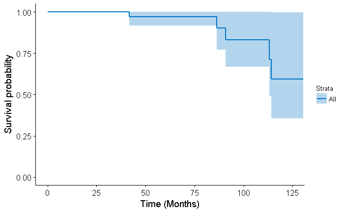

```r
uni_var(test_var = "TNM_PATH_M", data_imp = data)
```

## Pathologic Stage Group

```r
uni_var(test_var = "TNM_PATH_STAGE_GROUP", data_imp = data)
```

```
_________________________________________________

## TNM_PATH_STAGE_GROUP
_________________________________________________
Call: survfit(formula = Surv(DX_LASTCONTACT_DEATH_MONTHS, PUF_VITAL_STATUS ==
    0) ~ TNM_PATH_STAGE_GROUP, data = data)

      n  events  median 0.95LCL 0.95UCL
     45       5      NA     113      NA

Call: survfit(formula = Surv(DX_LASTCONTACT_DEATH_MONTHS, PUF_VITAL_STATUS ==
    0) ~ TNM_PATH_STAGE_GROUP, data = data)

 time n.risk n.event survival std.err lower 95% CI upper 95% CI
   12     41       0    1.000  0.0000        1.000        1.000
   24     40       0    1.000  0.0000        1.000        1.000
   36     37       0    1.000  0.0000        1.000        1.000
   48     33       1    0.972  0.0274        0.920        1.000
   60     29       0    0.972  0.0274        0.920        1.000
  120      3       4    0.595  0.1573        0.355        0.999




## Univariable Cox Proportional Hazard Model for:  TNM_PATH_STAGE_GROUP

[1] "Only one level, no Cox model performed"





## Unadjusted Kaplan Meier Overall Survival Curve for:  TNM_PATH_STAGE_GROUP
```

## Margins

```
_________________________________________________

## MARGINS
_________________________________________________
Call: survfit(formula = Surv(DX_LASTCONTACT_DEATH_MONTHS, PUF_VITAL_STATUS ==
    0) ~ MARGINS, data = data)

                           n events median 0.95LCL 0.95UCL
MARGINS=No Residual       27      2     NA   114.1      NA
MARGINS=Residual, NOS      5      0     NA      NA      NA
MARGINS=Microscopic Resid  6      3   86.4    41.6      NA
MARGINS=Not evaluable      3      0     NA      NA      NA
MARGINS=Unknown            4      0     NA      NA      NA

Call: survfit(formula = Surv(DX_LASTCONTACT_DEATH_MONTHS, PUF_VITAL_STATUS ==
    0) ~ MARGINS, data = data)

                MARGINS=No Residual
 time n.risk n.event survival std.err lower 95% CI upper 95% CI
   12     25       0     1.00   0.000        1.000            1
   24     24       0     1.00   0.000        1.000            1
   36     22       0     1.00   0.000        1.000            1
   48     20       0     1.00   0.000        1.000            1
   60     20       0     1.00   0.000        1.000            1
  120      3       2     0.72   0.178        0.444            1

                MARGINS=Residual, NOS
 time n.risk n.event survival std.err lower 95% CI upper 95% CI
   12      5       0        1       0            1            1
   24      5       0        1       0            1            1
   36      5       0        1       0            1            1
   48      5       0        1       0            1            1
   60      5       0        1       0            1            1

                MARGINS=Microscopic Resid
 time n.risk n.event survival std.err lower 95% CI upper 95% CI
   12      5       0     1.00   0.000        1.000            1
   24      5       0     1.00   0.000        1.000            1
   36      4       0     1.00   0.000        1.000            1
   48      3       1     0.75   0.217        0.426            1
   60      2       0     0.75   0.217        0.426            1

                MARGINS=Not evaluable
 time n.risk n.event survival std.err lower 95% CI upper 95% CI
   12      3       0        1       0            1            1
   24      3       0        1       0            1            1
   36      3       0        1       0            1            1
   48      2       0        1       0            1            1

                MARGINS=Unknown
 time n.risk n.event survival std.err lower 95% CI upper 95% CI
   12      3       0        1       0            1            1
   24      3       0        1       0            1            1
   36      3       0        1       0            1            1
   48      3       0        1       0            1            1
   60      2       0        1       0            1            1





## Univariable Cox Proportional Hazard Model for:  MARGINS
```

```
Ran out of iterations and did not converge
```

```
Call:
coxph(formula = Surv(DX_LASTCONTACT_DEATH_MONTHS, PUF_VITAL_STATUS ==
    0) ~ MARGINS, data = data)

  n= 45, number of events= 5

                               coef  exp(coef)   se(coef)      z Pr(>|z|)
MARGINSResidual, NOS     -1.700e+01  4.135e-08  7.716e+03 -0.002    0.998
MARGINSMicroscopic Resid  2.925e+00  1.864e+01  1.165e+00  2.511    0.012 *
MARGINSNot evaluable     -1.988e+01  2.322e-09  1.442e+05  0.000    1.000
MARGINSUnknown           -1.988e+01  2.322e-09  1.177e+05  0.000    1.000
---
Signif. codes:  0 *** 0.001 ** 0.01 * 0.05 . 0.1   1

                         exp(coef) exp(-coef) lower .95 upper .95
MARGINSResidual, NOS     4.135e-08  2.418e+07       0.0       Inf
MARGINSMicroscopic Resid 1.864e+01  5.365e-02       1.9     182.9
MARGINSNot evaluable     2.322e-09  4.307e+08       0.0       Inf
MARGINSUnknown           2.322e-09  4.307e+08       0.0       Inf

Concordance= 0.866  (se = 0.144 )
Rsquare= 0.19   (max possible= 0.427 )
Likelihood ratio test= 9.5  on 4 df,   p=0.04984
Wald test            = 6.3  on 4 df,   p=0.1775
Score (logrank) test = 15.59  on 4 df,   p=0.003617
```

[output not shown]

```
## Unadjusted Kaplan Meier Overall Survival Curve for:  MARGINS
```

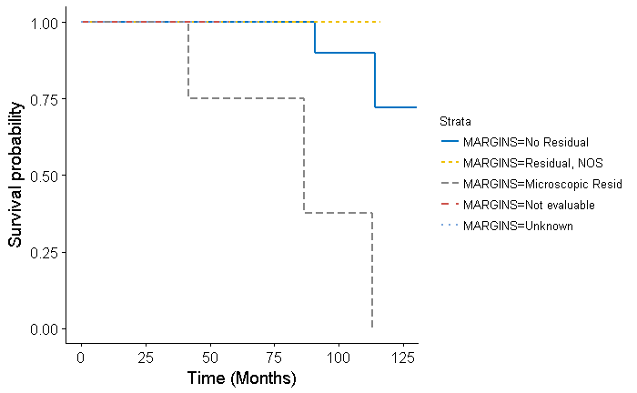

```r
uni_var(test_var = "MARGINS", data_imp = data)
```